# nucleosome and molecule-cluster entropy

This analysis calculates nucleosome entropy (first 500 bp downstream of the TSS) and per gene entropy (1kb around the TSS using cluster proportions)

```r
knitr::opts_chunk$set(echo = TRUE, error = FALSE, message = FALSE, warning = TRUE)
suppressPackageStartupMessages({library(data.table); library(ggplot2); library(patchwork)})
setDTthreads(1L)

PROJECT <- "/project/spott/cshan/fiber-seq"
OUT <- Sys.getenv("ENTROPY_OUT", file.path(PROJECT, "LCL_project/entropy/nucleosome_entropy"))
TABLES <- file.path(OUT, "tables")
PLOTS <- file.path(OUT, "plots")

dir.create(PLOTS, recursive = TRUE, showWarnings = FALSE)

source(file.path(PROJECT, "code/parsing_functions/plotting_functions.r"))
GROUPS <- c("housekeeping", "cell_type_specific", "not_expressed")
GROUP_LABELS <- c(housekeeping = "Housekeeping", cell_type_specific = "Cell-type-specific",
                  not_expressed = "Not expressed")
GROUP_COLORS <- c(housekeeping = "#1B9E77", cell_type_specific = "#D95F02", not_expressed = "#7570B3")
HMAX <- log2(500)
theme_set(theme_fiberseq(base_size = 11, overrides = list(
  plot.title = element_text(face = "bold"), plot.caption = element_text(hjust = 0),
  legend.position = "bottom", strip.background = element_rect(fill = "#F2F2F2", colour = NA))))
write_table <- function(d, name) fwrite(d, file.path(TABLES, name), sep = "\t", na = "NA")
save_pdf <- function(p, name, width = 10, height = 7) {
  save_figure(p, file.path(PLOTS, name), width = width, height = height, device = "pdf",
              useDingbats = FALSE)
}
ranking_height <- function(d) max(10, nrow(d) * .13 + 2)
# One metric by category (x = factor column), one jittered point per gene, black diamond =
# median; same style as 01_gene_group_entropy.pdf. labels maps x levels to axis names
plot_box_by_group <- function(d, metric, x, colors, ylab, title, labels = NULL, hline = NULL) {
  z <- d[is.finite(get(metric))]
  s <- z[, .(n_genes = .N, median_value = median(get(metric))), by = x]
  names_x <- if (is.null(labels)) as.character(s[[x]]) else labels[as.character(s[[x]])]
  labs_x <- setNames(sprintf("%s\nn = %d genes", names_x, s$n_genes), as.character(s[[x]]))
  y_range <- range(c(z[[metric]], hline))
  label_y <- y_range[2] + .05 * diff(y_range)
  p <- ggplot(z, aes(.data[[x]], .data[[metric]], colour = .data[[x]]))
  if (!is.null(hline)) p <- p + geom_hline(yintercept = hline, linetype = 2, colour = "#888888")
  p + geom_boxplot(aes(fill = .data[[x]]), width = .46, outlier.shape = NA, alpha = .15, show.legend = FALSE) +
    geom_point(position = position_jitter(width = .13, seed = 12), size = 1.8, alpha = .65, show.legend = FALSE) +
    geom_point(data = s, aes(.data[[x]], median_value), inherit.aes = FALSE, shape = 18, size = 4) +
    geom_text(data = s, aes(.data[[x]], label_y, label = sprintf("Median %.4f", median_value)),
              inherit.aes = FALSE, size = 3.6) +
    scale_colour_manual(values = colors) + scale_fill_manual(values = colors) +
    scale_x_discrete(labels = labs_x) +
    labs(x = NULL, y = ylab, title = title)
}

# Raw (left) and normalized (right) versions of every figure. A spec names the two columns,
# their axis labels, their maxima (dashed line, NULL = none) and the subtitle
MOTIF_COLORS <- c(TATA = "#E41A1C", SP1 = "#377EB8", ETS = "#4DAF4A", NFY = "#984EA3",
                  NRF1 = "#FF7F00", CREB = "#A65628", YY1 = "#F781BF", ZNF143 = "#1B9E77")
FP_CLASSES <- c("10-30 bp", "30-60 bp", "60-80 bp")
FP_CLASS_NAMES <- c("10-<30 bp", "30-<60 bp", "60-80 bp")
pair_panels <- function(raw, normalized, spec, title) {
  (raw + labs(title = "Raw")) + (normalized + labs(title = "Normalized")) +
    plot_layout(guides = "collect") +
    plot_annotation(title = title, subtitle = spec$subtitle,
                    theme = theme(plot.title = element_text(face = "bold"))) &
    theme(legend.position = "bottom")
}
pair_of <- function(panel, spec, title)
  pair_panels(panel(spec$raw, spec$raw_label, spec$raw_max),
              panel(spec$normalized, spec$normalized_label, spec$normalized_max), spec, title)
group_colour <- scale_colour_manual(values = GROUP_COLORS, breaks = GROUPS, labels = GROUP_LABELS,
                                    name = "Gene group")

# d: one row per gene with group, puffin_motif, plus1_start_mean_bp and the spec columns
plot_group_pair <- function(d, spec) {
  z <- copy(d)[, group := factor(group, GROUPS)]
  pair_of(function(m, lab, hl) plot_box_by_group(z, m, "group", GROUP_COLORS, lab, NULL,
            labels = GROUP_LABELS, hline = hl), spec, paste(spec$name, "by gene group"))
}
# Motifs ordered by the median of the raw metric in both panels
plot_motif_pair <- function(d, spec) {
  motif_order <- d[, .(m = median(get(spec$raw))), by = puffin_motif][order(m), puffin_motif]
  z <- copy(d)[, puffin_motif := factor(puffin_motif, motif_order)]
  pair_of(function(m, lab, hl) plot_box_by_group(z, m, "puffin_motif", MOTIF_COLORS, lab, NULL, hline = hl) +
            labs(x = "Puffin dominant motif (U1 excluded from class assignment)"),
          spec, paste(spec$name, "by Puffin promoter motif"))
}
plot_plus1_pair <- function(d, spec) {
  z <- d[is.finite(plus1_start_mean_bp)]
  pair_of(function(m, lab, hl) ggplot(z, aes(.data[[m]], plus1_start_mean_bp, colour = group)) +
            geom_point(size = 2, alpha = .75) + group_colour +
            labs(x = lab, y = "Mean +1 nucleosome start position (bp downstream of TSS)"),
          spec, paste(spec$name, "and +1 nucleosome start position"))
}
# fp: one row per gene and footprint class, with fraction_with_footprint and the spec columns
plot_footprint_pair <- function(fp, spec) {
  z <- copy(fp)[, footprint_class := factor(footprint_class, FP_CLASSES)]
  n <- z[, .(n_genes = uniqueN(gene_name)), by = footprint_class]
  strip <- setNames(sprintf("%s\nn = %d genes", FP_CLASS_NAMES,
                            n$n_genes[match(FP_CLASSES, n$footprint_class)]), FP_CLASSES)
  pair_of(function(m, lab, hl) ggplot(z, aes(.data[[m]], fraction_with_footprint, colour = group)) +
            geom_point(size = 1.8, alpha = .7) +
            facet_wrap(~ footprint_class, ncol = 1, labeller = labeller(footprint_class = strip)) +
            group_colour + scale_y_continuous(limits = c(0, 1), breaks = seq(0, 1, .25)) +
            labs(x = lab, y = "Fraction of fibers with a short footprint\noverlapping TSS -100 to +100 bp"),
          spec, paste(spec$name, "and short-footprint presence near the TSS"))
}
# Each panel has its own gene order, highest at the top
plot_ranking_pair <- function(d, spec) {
  pair_of(function(m, lab, hl) {
    z <- d[is.finite(get(m))][order(get(m), gene_name)]
    z[, gene := factor(gene_name, levels = gene_name)]
    ggplot(z, aes(.data[[m]], gene, colour = group)) + geom_point(size = 1.6) + group_colour +
      labs(x = lab, y = NULL) + theme(axis.text.y = element_text(size = 6))
  }, spec, paste0(spec$name, ": gene ranking"))
}
NUCLEOSOME_SPEC <- list(name = "Nucleosome entropy",
  raw = "nucleosome_entropy_bits", raw_label = "Nucleosome entropy (bits)", raw_max = HMAX,
  normalized = "normalized_nucleosome_entropy", normalized_label = "Normalized nucleosome entropy",
  normalized_max = 1,
  subtitle = "Left: raw entropy H (bits, TSS +1 to +500 bp)  |  Right: normalized entropy H / log2(500)")

all_genes <- fread(file.path(TABLES, "gene_entropy.tsv"))
all_levels <- fread(file.path(TABLES, "nucleosome_entropy.tsv"))
stopifnot(!anyDuplicated(all_genes$gene_name))
genes <- all_genes[status == "complete" & is.finite(nucleosome_entropy_bits)]
stopifnot(nrow(genes) > 0L, all(genes$group %in% GROUPS),
          all(genes$nucleosome_entropy_bits >= 0 & genes$nucleosome_entropy_bits <= HMAX + 1e-10))
EXCLUSION <- paste0(nrow(genes), " valid genes; ", nrow(all_genes) - nrow(genes), " excluded.")


pf <- fread(file.path(PROJECT, "LCL_project/pausing/PolII/promoter_annotation/tables/04a_puffin_motif_scores.tsv"),
            check.names = FALSE)
stopifnot(!anyDuplicated(pf$gene_name))
ix <- match(genes$gene_name, pf$gene_name)
stopifnot(!anyNA(ix), all(genes$chrom == pf$chrom[ix]), all(genes$tss == pf$puffin_tss0[ix] + 1L),
          all(genes$strand == pf$strand[ix]))
genes <- merge(genes, pf[, .(gene_name, group_excl_U1)], by = "gene_name")
setnames(genes, "group_excl_U1", "puffin_motif")
genes[, mean_nucleosome_occupancy := total_nucleosome_occupancy_signal / 500]
write_table(genes[order(nucleosome_entropy_bits, gene_name)], "gene_entropy_features.tsv")
```

# Nucleosome entropy

Nucleosome entropy measures how evenly nucleosome occupancy is spread over the first 500 bp downstream of the TSS. It is calculated by `code/entropy/nucleosome/nucleosome_entropy.R` (run via `nucleosome/run_entropy.sh`)

**low entropy** = well-positioned nucleosomes, **high entropy** = dispersed nucleosomes

**Input files**

- Genes: `code/pausing/PolII/example_gene_list.tsv` (150 genes, three groups)
- TSS and strand: `LCL_project/pausing/PolII/read_features/tables/gene_features.tsv`
- included reads: `LCL_project/pausing/PolII/read_features/tables/read_features.tsv.gz`
- fibertools nucleosome: fibertools `<fire_dir>/extracted_results/nuc_by_chr/<sample>.ft_extracted_nuc.<chr>.bed.gz`
- Cluster labels: `LCL_project/pausing/PolII/recurrent_patterns/tables/<gene>/read_features.tsv.gz`
- FiberHMM v1 footprints: `LCL_Fiber_seq/FiberHMM/merged/<sample>/joint_trained_results/<sample>_<chr>_fp.bed.gz`
- Puffin motif classes: `LCL_project/pausing/PolII/promoter_annotation/tables/04a_puffin_motif_scores.tsv`
1. For each gene, take the saved reads. A gene is analysed only if it has $>$ 20 saved reads and $>$ 1 Leiden cluster; otherwise its status is `below_min_reads_or_clusters` and $H$ is NA
2. Query each sample’s nucleosome BED12 at TSS +/-1000 bp , and keep nucleosomes of 130-160 bp
3. Convert coordinates to transcription-oriented offsets from the TSS (minus-strand genes are reversed), so that $x = 1, \dots, 500$ are the bases downstream of the TSS
4. At each base $x$, count the fibers covering it, $c_x$, and the fibers with a retained nucleosome over it, $n_x$. Each fiber counts at most once per base. A saved read with no fibertools nucleosome record counts as covering with no nucleosomes. The occupancy is
   $$o_x = \frac{n_x}{c_x}.$$
5. The occupancy profile is turned into a probability distribution over positions,
   $$p_x =
   \frac{o_x}{\sum_{y=1}^{500} o_y},$$
   and its Shannon entropy in bits is
   $$H = -\sum_{x=1}^{500} p_x \log_2
   p_x, \qquad 0 \log_2 0 = 0.$$
   - $H$ is computed from 500 single-base fractions
   - the maximum entropy is $\log_2 500 = 8.966$ bits, reached when occupancy is identical at every base
   - lower $H$ means occupancy is concentrated in fewer positions (well-positioned nucleosomes)
   - normalized entropy $H_{\text{norm}} = H / \log_2 500$ runs from 0 to 1 (1 = identical occupancy at every base)
   - A result is `complete` only if all 500 bases are covered ($c_x > 0$) and $\sum_x o_x > 0$. Otherwise its status is `incomplete_coverage`, `no_fibers` or `zero_nucleosome_occupancy`, and $H$ is NA
6. Steps 4-5 are repeated at two levels:
1. gene (all reads)
2. cluster - the reads in one original per-gene Leiden cluster

**features**

1. +1 nucleosome start: per fiber, the first 130-160 bp nucleosome that starts at +1..+299 bp and does not cover the TSS
- mean start over fibers that have one
2. footprint fraction: footprints in the size classes [10,30), [30,60) and [60,80] bp. A fiber is a success for a class if at least one footprint of that class overlaps TSS -100..+100 bp by $\ge 1$ bp. The fraction is
   $$f = \frac{\#\{\text{fibers spanning all 201 bases
   with }\ge 1\text{ qualifying footprint}\}}
   {\#\{\text{fibers spanning all 201 bases}\}}.$$

**Output tables** (`LCL_project/entropy/nucleosome_entropy/tables/`)

1. `gene_entropy.tsv` (gene level)
2. `nucleosome_entropy.tsv` (all levels)
3. `occupancy_per_base.tsv.gz` (per-base $c_x$, $n_x$, $o_x$, $p_x$) and `short_footprint_fractions.tsv`
4. `gene_entropy.tsv`
- One row per gene (150 genes)
- `n_fibers` is the number of reads and `total_nucleosome_occupancy_signal` is $\sum_x o_x$. `nucleosome_entropy_bits` is $H$ and `normalized_nucleosome_entropy` is $H_{\text{norm}}$
- `plus1_start_mean_bp` / `plus1_start_sd_bp` (+1 nucleosome start average across all reads contain +1 nucleosome for the gene)
- tss_nucleosome_free_fraction` (fraction of reads with no nucleosome over the TSS)

-`promoter_m6a_core` (mean per-read m6A rate in TSS -200..+200 bp) and the gene’s TPM

```r
knitr::kable(head(all_genes[, .(gene_name, group, n_fibers, total_nucleosome_occupancy_signal,
  nucleosome_entropy_bits, plus1_start_mean_bp, tss_nucleosome_free_fraction)]))
```

| gene_name | group | n_fibers | total_nucleosome_occupancy_signal | nucleosome_entropy_bits | plus1_start_mean_bp | tss_nucleosome_free_fraction |
| --- | --- | --- | --- | --- | --- | --- |
| CD74 | cell_type_specific | 453 | 118.8698 | 8.917232 | 133.8655 | 0.9161148 |
| HLA-DRA | cell_type_specific | 101 | 134.7525 | 8.875063 | 123.2264 | 0.8910891 |
| HLA-DRB1 | cell_type_specific | 134 | 148.7612 | 8.915487 | 146.6769 | 0.8208955 |
| HLA-DQA1 | cell_type_specific | 205 | 133.9610 | 8.882042 | 123.5268 | 0.9317073 |
| IRF4 | cell_type_specific | 537 | 121.1508 | 8.865196 | 133.3436 | 0.9739292 |
| HLA-DPB1 | cell_type_specific | 61 | 175.5574 | 8.922795 | 109.3438 | 0.7213115 |

2. `nucleosome_entropy.tsv`
- one row per gene at every level: `level` is `gene` or `cluster`
- For cluster, `eligible` is defind if gene $\ge$ 50 reads, cluster $\ge$ 20 reads, $\le$ 4 empty bins

```r
knitr::kable(all_levels[gene_name == all_levels$gene_name[1], .(gene_name, level, cluster,
  eligible, n_fibers, nucleosome_entropy_bits)])
```

| gene_name | level | cluster | eligible | n_fibers | nucleosome_entropy_bits |
| --- | --- | --- | --- | --- | --- |
| CD74 | gene | NA | NA | 453 | 8.917232 |
| CD74 | cluster | cluster1 | TRUE | 121 | 8.912379 |
| CD74 | cluster | cluster2 | TRUE | 118 | 8.735691 |
| CD74 | cluster | cluster3 | TRUE | 108 | 8.736602 |
| CD74 | cluster | cluster4 | TRUE | 106 | 8.881373 |

3. `occupancy_per_base.tsv.gz`
- 500 rows ($x$ = `offset` 1..500 downstream of the TSS) for each gene and cluster
- `offset` is the distance in bp from the TSS in the direction of transcription; the TSS itself is offset 0 and is not included. `genomic_position` is `tss + offset` for plus-strand genes and `tss - offset` for minus-strand genes, so the same offset means the same distance into the transcribed region for every gene
- `covering_fibers` is $c_x$, `nucleosome_fibers` is $n_x$, `occupancy` is $o_x = n_x / c_x$ and `probability` is $p_x$
- entropy is calculated from $-\sum_x p_x \log_2 p_x$

```r
occupancy <- fread(file.path(TABLES, "occupancy_per_base.tsv.gz"))

knitr::kable(head(occupancy[, .(gene_name, level, offset, genomic_position, covering_fibers,
  nucleosome_fibers, occupancy, probability)]))
```

| gene_name | level | offset | genomic_position | covering_fibers | nucleosome_fibers | occupancy | probability |
| --- | --- | --- | --- | --- | --- | --- | --- |
| CD74 | gene | 1 | 150412750 | 453 | 40 | 0.0883002 | 0.0007428 |
| CD74 | gene | 2 | 150412749 | 453 | 40 | 0.0883002 | 0.0007428 |
| CD74 | gene | 3 | 150412748 | 453 | 43 | 0.0949227 | 0.0007985 |
| CD74 | gene | 4 | 150412747 | 453 | 46 | 0.1015453 | 0.0008543 |
| CD74 | gene | 5 | 150412746 | 453 | 46 | 0.1015453 | 0.0008543 |
| CD74 | gene | 6 | 150412745 | 453 | 46 | 0.1015453 | 0.0008543 |

4. `short_footprint_fractions.tsv`
- Three rows per gene, one per footprint size class (`footprint_class`: 10-30, 30-60 and 60-80 bp)
- `n_fibers` is all of the gene’s reads, `n_evaluable_fibers` the reads spanning all 201 bases of TSS -100..+100 bp (the denominator), `n_fibers_with_footprint` the evaluable reads with at least one footprint of that class overlapping the window
- `fraction_with_footprint` their ratio $f$

```r
short_fp <- fread(file.path(TABLES, "short_footprint_fractions.tsv"))
knitr::kable(head(short_fp[, .(gene_name, footprint_class, n_fibers, n_evaluable_fibers,
  n_fibers_with_footprint, fraction_with_footprint)]), digits = 3,
  caption = "short_footprint_fractions.tsv: first rows.")
```

short_footprint_fractions.tsv: first rows.

| gene_name | footprint_class | n_fibers | n_evaluable_fibers | n_fibers_with_footprint | fraction_with_footprint |
| --- | --- | --- | --- | --- | --- |
| CD74 | 10-30 bp | 453 | 453 | 234 | 0.517 |
| CD74 | 30-60 bp | 453 | 453 | 171 | 0.377 |
| CD74 | 60-80 bp | 453 | 453 | 41 | 0.091 |
| HLA-DRA | 10-30 bp | 101 | 101 | 76 | 0.752 |
| HLA-DRA | 30-60 bp | 101 | 101 | 29 | 0.287 |
| HLA-DRA | 60-80 bp | 101 | 101 | 35 | 0.347 |

Genes are ranked across all gene groups using entropy, without an additional filter for read coverage

Two genes have no entropy and are not included in any entropy analysis (148 genes remain):

- SLC44A4 (`no_fibers`): only 6 reads overlap TSS -1000..+1000 bp across all 31 samples and none spans the full window, so the PolII read-feature step (which needs at least 3 full-span reads) saved no reads for this gene
- HLA-DMA (`below_min_reads_or_clusters`): only 5 saved reads, all in one Leiden cluster

CLEC12B is included: one of its 683 saved reads (sample AL28) has almost no m6A (2 calls over 8.9 kb), so fibertools wrote no nucleosome record for it; this read counts as covering the window with no nucleosomes

```r
extreme_genes <- rbindlist(list(
  head(genes[order(-nucleosome_entropy_bits, gene_name)], 5L)[, tail := "Highest"],
  head(genes[order(nucleosome_entropy_bits, gene_name)], 5L)[, tail := "Lowest"]
))
extreme_genes[, rank := seq_len(.N), by = tail]
extreme_table <- extreme_genes[, .(tail, rank, gene_name, group, puffin_motif,
                                  n_fibers, nucleosome_entropy_bits)]
write_table(extreme_table, "highest_lowest_5_gene_entropy.tsv")
knitr::kable(extreme_table, row.names = FALSE, digits = 4,
  col.names = c("Entropy", "Rank", "Gene", "Gene group", "Puffin motif", "Fibers", "Entropy (bits)"),
  caption = "Five highest- and five lowest-entropy genes across all valid genes.")
```

Five highest- and five lowest-entropy genes across all valid genes.

| Entropy | Rank | Gene | Gene group | Puffin motif | Fibers | Entropy (bits) |
| --- | --- | --- | --- | --- | --- | --- |
| Highest | 1 | JAKMIP3 | not_expressed | SP1 | 467 | 8.9631 |
| Highest | 2 | UBAP1L | not_expressed | CREB | 599 | 8.9609 |
| Highest | 3 | HNF4A | not_expressed | TATA | 503 | 8.9606 |
| Highest | 4 | MYL11 | not_expressed | TATA | 384 | 8.9602 |
| Highest | 5 | GDF5 | not_expressed | TATA | 449 | 8.9599 |
| Lowest | 1 | CTCF | housekeeping | SP1 | 445 | 8.6039 |
| Lowest | 2 | RELB | cell_type_specific | SP1 | 474 | 8.6760 |
| Lowest | 3 | MAK | not_expressed | TATA | 586 | 8.6960 |
| Lowest | 4 | PSMB1 | housekeeping | ETS | 599 | 8.7281 |
| Lowest | 5 | PSMD4 | housekeeping | NFY | 612 | 8.7511 |

### 1. nucleosome entropy by gene group

Each point is one gene. black diamond marks the median. Left: raw entropy, right: normalized entropy

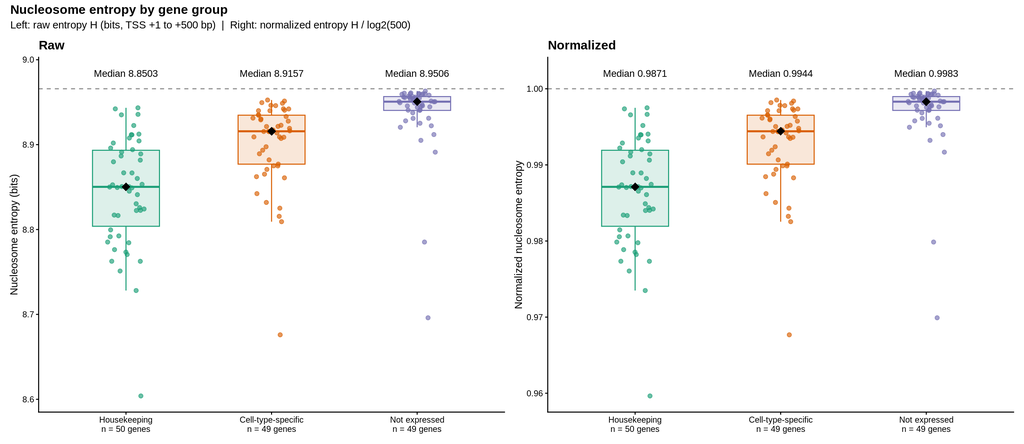

```r
group_summary <- genes[, .(n_genes = .N, n_fibers = sum(n_fibers),
  median_entropy = median(nucleosome_entropy_bits), q25 = quantile(nucleosome_entropy_bits, .25),
  q75 = quantile(nucleosome_entropy_bits, .75), min_entropy = min(nucleosome_entropy_bits),
  max_entropy = max(nucleosome_entropy_bits)), by = group]
write_table(group_summary, "gene_group_summary.tsv")
p <- plot_group_pair(genes, NUCLEOSOME_SPEC)
save_pdf(p, "01_gene_group_entropy.pdf", 15, 6.5)

p
```

### 2. nucleosome entropy by puffin dominant motif

Each point is one gene, grouped by its Puffin dominant motif. Motifs are ordered by median raw gene entropy. Left: raw entropy, right: normalized entropy

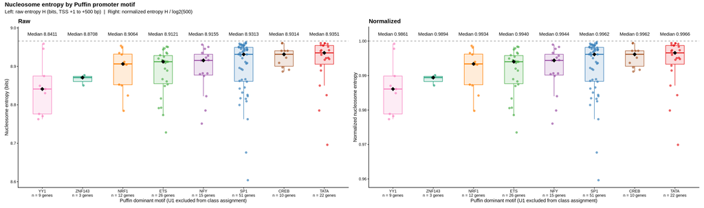

```r
motif_summary <- genes[, .(n_genes = .N, median_entropy = median(nucleosome_entropy_bits),
  q25 = quantile(nucleosome_entropy_bits, .25), q75 = quantile(nucleosome_entropy_bits, .75)),
  by = puffin_motif][order(median_entropy)]
write_table(motif_summary, "puffin_motif_entropy_summary.tsv")
p <- plot_motif_pair(genes, NUCLEOSOME_SPEC)
save_pdf(p, "02_entropy_by_puffin_motif.pdf", 22, 6.5)

p
```

### 3. nucleosome entropy and +1 nucleosome start position

Each point is one gene. The +1 coordinate is the mean of the per-fiber first nucleosome starts at +1..+299 bp, excluding nucleosomes covering the TSS. Left: raw entropy, right: normalized entropy

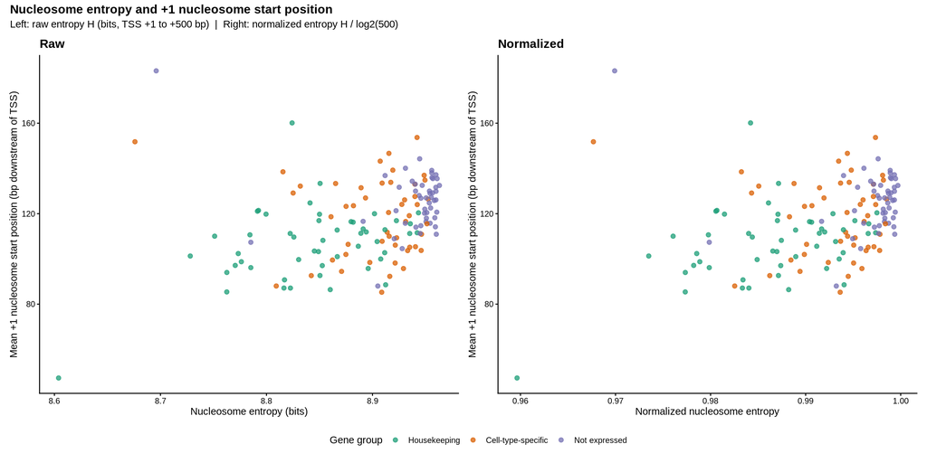

```r
plus1_genes <- genes[is.finite(plus1_start_mean_bp), .(gene_name, group, n_fibers,
  n_plus1_fibers, nucleosome_entropy_bits, plus1_start_mean_bp)]
write_table(plus1_genes, "entropy_vs_plus1_start.tsv")
p <- plot_plus1_pair(genes, NUCLEOSOME_SPEC)
save_pdf(p, "03_entropy_vs_plus1_start.pdf", 14, 7)

p
```

### 4. nucleosome entropy and footprint presence at promoters

The footprint window is -100..+100 bp, the entropy window remains +1..+500 bp

The y-axis measures the fraction of fully spanning reads with at least one footprint overlapping the promoter window. It does not measure the fraction of bases covered or the number of calls. Left: raw entropy, right: normalized entropy

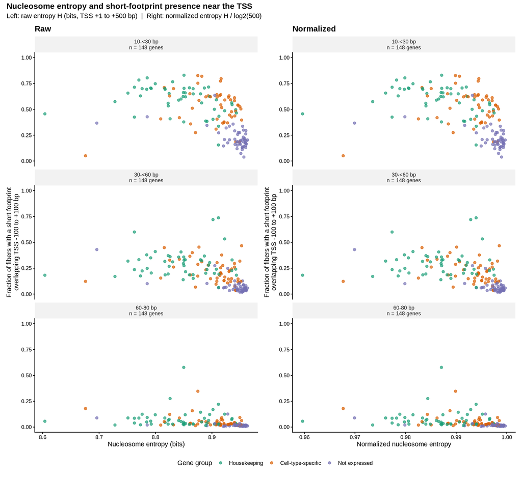

```r
fp_path <- file.path(TABLES, "short_footprint_fractions.tsv")
if (!file.exists(fp_path)) stop("Generate footprint fractions first: bash code/entropy/nucleosome/run_entropy.sh --footprints-only")
fp_all <- fread(fp_path)
stopifnot(!anyDuplicated(fp_all[, .(gene_name, footprint_class)]),
          all(genes$gene_name %in% fp_all$gene_name),
          all(fp_all$footprint_window_start_offset == -100L),
          all(fp_all$footprint_window_end_offset == 100L), all(fp_all$footprint_window_bp == 201L))
fp_genes <- merge(fp_all, genes[, .(gene_name, expected_entropy = nucleosome_entropy_bits,
                                   expected_fibers = n_fibers)], by = "gene_name")
stopifnot(all(abs(fp_genes$nucleosome_entropy_bits - fp_genes$expected_entropy) < 1e-10),
          all(fp_genes$n_fibers == fp_genes$expected_fibers))
fp_genes <- fp_genes[footprint_status == "complete" & is.finite(fraction_with_footprint)]
stopifnot(all(fp_genes$fraction_with_footprint >= 0 & fp_genes$fraction_with_footprint <= 1))
fp_genes[, c("expected_entropy", "expected_fibers") := NULL]
write_table(fp_genes, "entropy_vs_short_footprints.tsv")
fp_genes <- merge(fp_genes, genes[, .(gene_name, normalized_nucleosome_entropy)], by = "gene_name")
p <- plot_footprint_pair(fp_genes, NUCLEOSOME_SPEC)
save_pdf(p, "04_entropy_vs_short_footprints.pdf", 12, 11)
message("Generated PDF figures in ", PLOTS, "; supporting tables in ", TABLES)

p
```

higher nucleosome entropy is associated with fewer promoter short footprints and a farther-downstream mean +1 nucleosome start

footprint columns are percentages of fibers with at least one overlapping footprint in TSS -100 to +100 bp

```r
class_order <- c("TATA", "SP1", "CREB", "NFY", "NRF1", "ETS", "YY1", "ZNF143")
fp_wide <- dcast(fp_genes, gene_name ~ footprint_class, value.var = "fraction_with_footprint")
stopifnot(all(FP_CLASSES %in% names(fp_wide)))
setnames(fp_wide, FP_CLASSES, c("fp10", "fp30", "fp60"))
promoter_features <- merge(genes[, .(gene_name, group, puffin_motif,
  nucleosome_entropy_bits, plus1_start_mean_bp)], fp_wide, by = "gene_name", all.x = TRUE)
stopifnot(nrow(promoter_features) == nrow(genes),
          all(promoter_features$puffin_motif %in% class_order),
          all(is.finite(as.matrix(promoter_features[, .(nucleosome_entropy_bits,
            plus1_start_mean_bp, fp10, fp30, fp60)]))))
promoter_summary <- promoter_features[, .(n_genes = .N,
  n_not_expressed = sum(group == "not_expressed"),
  median_entropy_bits = median(nucleosome_entropy_bits),
  median_plus1_start_bp = median(plus1_start_mean_bp),
  median_fp10_percent = 100 * median(fp10),
  median_fp30_percent = 100 * median(fp30),
  median_fp60_percent = 100 * median(fp60)), by = puffin_motif]
promoter_summary <- promoter_summary[order(match(puffin_motif, class_order))]
write_table(promoter_summary, "puffin_promoter_class_features_summary.tsv")
write_table(promoter_features, "puffin_promoter_class_gene_features.tsv")
knitr::kable(promoter_summary[, .(puffin_motif, n_genes, median_entropy_bits,
  median_plus1_start_bp, median_fp10_percent, median_fp30_percent, median_fp60_percent)],
  digits = c(0, 0, 4, 1, 1, 1, 1), row.names = FALSE,
  col.names = c("Motif", "Genes", "Entropy (bits)", "+1 start (bp)",
                "10-<30 bp (%)", "30-<60 bp (%)", "60-80 bp (%)"),
  caption = "Median gene-level features by Puffin promoter class.")
```

Median gene-level features by Puffin promoter class.

| Motif | Genes | Entropy (bits) | +1 start (bp) | 10-<30 bp (%) | 30-<60 bp (%) | 60-80 bp (%) |
| --- | --- | --- | --- | --- | --- | --- |
| TATA | 22 | 8.9351 | 126.0 | 37.2 | 17.5 | 2.6 |
| SP1 | 51 | 8.9313 | 119.8 | 37.2 | 15.4 | 2.7 |
| CREB | 10 | 8.9314 | 116.8 | 39.0 | 11.5 | 2.2 |
| NFY | 15 | 8.9155 | 116.5 | 56.3 | 19.4 | 2.9 |
| NRF1 | 12 | 8.9064 | 114.3 | 54.6 | 22.0 | 3.3 |
| ETS | 26 | 8.9121 | 111.9 | 58.3 | 17.3 | 2.7 |
| YY1 | 9 | 8.8411 | 102.0 | 70.0 | 23.6 | 3.9 |
| ZNF143 | 3 | 8.8708 | 94.5 | 58.6 | 27.4 | 2.2 |

### 5. Individual Leiden-cluster nucleosome entropy examples

```r
cluster_out <- Sys.getenv("CLUSTER_ENTROPY_OUT",
  file.path(PROJECT, "LCL_project/entropy/leiden_clusters_all_genes"))
cluster_results <- fread(file.path(cluster_out, "tables/nucleosome_entropy.tsv"))
individual_clusters <- cluster_results[level == "cluster" & status == "complete" &
  is.finite(nucleosome_entropy_bits)]
stopifnot(nrow(individual_clusters) > 0L,
          !anyDuplicated(individual_clusters[, .(gene_name, cluster)]))
selected_keys <- data.table(gene_name = c("IL21R", "CTCF", "TNFRSF13B"),
                           cluster = c("cluster5", "cluster4", "cluster1"), display_order = 1:3)
selected_clusters <- merge(selected_keys, individual_clusters, by = c("gene_name", "cluster"))
stopifnot(nrow(selected_clusters) == 3L)
setorder(selected_clusters, display_order)
profiles <- fread(file.path(cluster_out, "tables/occupancy_per_base.tsv.gz"))
profiles <- merge(profiles[level == "cluster"], selected_clusters[, .(gene_name, cluster,
  expected_entropy = nucleosome_entropy_bits, expected_fibers = n_fibers, display_order)],
  by = c("gene_name", "cluster"))
setorder(profiles, display_order, offset)
checks <- profiles[, .(positions = .N, unique_positions = uniqueN(offset),
  first = min(offset), last = max(offset),
  H = -sum(probability[probability > 0] * log2(probability[probability > 0])),
  expected_H = unique(expected_entropy), probability_sum = sum(probability),
  full_coverage = all(covering_fibers == expected_fibers),
  probability_matches = max(abs(probability - occupancy / sum(occupancy)))), by = .(gene_name, cluster)]
stopifnot(all(checks$positions == 500L), all(checks$unique_positions == 500L),
  all(checks$first == 1L), all(checks$last == 500L), all(checks$full_coverage),
  all(abs(checks$H - checks$expected_H) < 1e-10),
  all(abs(checks$probability_sum - 1) < 1e-10), all(checks$probability_matches < 1e-10))
write_table(selected_clusters, "selected_cluster_entropy_examples.tsv")
write_table(profiles, "selected_cluster_occupancy_profiles.tsv")
```

IL21R cluster5 has the lowest and TNFRSF13B cluster1 the highest entropy

- CTCF cluster4 is a low-entropy example

```r
knitr::kable(selected_clusters[, .(gene_name, cluster, nucleosome_entropy_bits, n_fibers)],
  digits = 3, row.names = FALSE,
  col.names = c("Gene", "Cluster", "Nucleosome entropy (bits)", "Fibers"))
```

| Gene | Cluster | Nucleosome entropy (bits) | Fibers |
| --- | --- | --- | --- |
| IL21R | cluster5 | 7.422 | 36 |
| CTCF | cluster4 | 8.328 | 70 |
| TNFRSF13B | cluster1 | 8.959 | 188 |

function to plot selected gene cluster combination

```r
entropy_helpers <- new.env(parent = globalenv())
sys.source(file.path(PROJECT, "code/entropy/nucleosome/nucleosome_entropy.R"), envir = entropy_helpers)
pol2 <- new.env(parent = globalenv())
source(file.path(PROJECT, "code/pausing/PolII/pol2_pausing_functions.r"), local = pol2)

# Reads, m6A matrix, plot rows and nucleosome/footprint intervals of one selected cluster
load_selected_cluster <- function(g, samples, cohort) {
  assignments <- fread(file.path(PROJECT, "LCL_project/pausing/PolII/recurrent_patterns/tables",
    g$group, paste0(g$gene_name, "_read_clusters.tsv")))
  chosen <- assignments[cluster == g$cluster][order(clustered_row)]
  stopifnot(nrow(chosen) == g$n_fibers, !anyDuplicated(chosen$RID))
  reads <- cohort[gene == g$gene_name & RID %in% chosen$RID]
  stopifnot(nrow(reads) == g$n_fibers, setequal(reads$RID, chosen$RID))
  region <- data.frame(region_id = g$gene_name, chr = g$chrom,
    start = g$tss - 1001L, end = g$tss + 1000L,
    analysis_start = g$tss - 1000L, analysis_end = g$tss + 1000L,
    tss = g$tss, strand = g$strand, tss_source = g$tss_source)
  dat <- assemble_region_m6a(as.data.frame(samples), region, full_span = TRUE,
    positions = seq(region$analysis_start, region$analysis_end))
  stopifnot(all(chosen$RID %in% dat$rids_df$RID))
  rows <- pol2$example_rows(chosen$RID, dat$rids_df,
    factor(rep(g$cluster, nrow(chosen)), levels = g$cluster))
  relative <- function(x) {
    y <- as.data.table(x)
    rel <- pol2$to_relative(y$start, y$end, g$tss, rep(g$strand, nrow(y)))
    y[, `:=`(lo = rel$lo, hi = rel$hi, size = end - start)]
    y
  }
  bundle <- list(nucs = relative(entropy_helpers$load_nucleosomes(g, reads, samples)),
                 fp = relative(entropy_helpers$load_short_footprints(g, reads, window = c(-1000L, 1000L))))

  counts <- integer(500L)
  for (rid in reads$RID) {
    z <- bundle$nucs[RID == rid]
    occupied <- rep(FALSE, 500L)
    for (j in seq_len(nrow(z))) {
      lo <- max(1L, z$lo[j]); hi <- min(500L, z$hi[j])
      if (lo <= hi) occupied[lo:hi] <- TRUE
    }
    counts <- counts + occupied
  }
  expected <- profiles[gene_name == g$gene_name & cluster == g$cluster][order(offset)]
  stopifnot(identical(as.integer(counts), as.integer(expected$nucleosome_fibers)))
  title_g <- copy(g)
  title_g[, gene_name := sprintf("%s %s | H=%.3f bits | entropy +1..+500 bp",
    g$gene_name, g$cluster, g$nucleosome_entropy_bits)]
  # figure heights (in) used by plot_example_m6a() / plot_example_footprints() for one cluster
  heights <- c(m6a = 6 + 0.55, footprints = 1.6 + 0.65 + pol2$READ_ROW_IN * nrow(rows) + 0.15 + 1.2)
  list(g = title_g, gene = g$gene_name, cluster = g$cluster, dat = dat, rows = rows, bundle = bundle,
       heights = heights)
}

samples <- fread(pol2$SAMPLES)[, .(sample_name, fire_dir)]
cohort <- fread(file.path(PROJECT, "LCL_project/pausing/PolII/read_features/tables/read_features.tsv.gz"))
selected_data <- setNames(lapply(seq_len(nrow(selected_clusters)), function(i)
  load_selected_cluster(selected_clusters[i], samples, cohort)), selected_clusters$gene_name)
```

```r
pol2$footprint_caption <- function(g) NULL
pol2$save_figure <- function(plot, path, ..., draw = NULL) {
  # Footprint figures: more space between the title and the top m6A track
  if (inherits(plot, "patchwork"))
    plot <- plot + patchwork::plot_annotation(theme = theme(plot.title = element_text(margin = margin(b = 12))))
  # m6A heatmaps: hide the "cluster" row-annotation name, which overlaps the -1000 tick (the legend names it)
  if (inherits(plot, "Heatmap") && !is.null(plot@left_annotation))
    for (a in names(plot@left_annotation@anno_list))
      plot@left_annotation@anno_list[[a]]@name_param$show <- FALSE
  save_figure(plot, path, ..., draw = draw)
  # also draw on the current device: inline in RStudio, captured as the chunk figure when knitting
  if (is.null(draw)) print(plot) else draw(plot)
  invisible(path)
}

plot_selected_cluster <- function(x, panel, figure_number) {
  path <- file.path(PLOTS, sprintf("%02d_%s_%s_%s.pdf", figure_number, x$gene, x$cluster, panel))
  title <- function(g, view) sprintf("%s | %s | %s", g$gene_name, g$group, view)
  if (panel == "m6a") {
    pol2$example_labels <- function(g, view, n) c(title = title(g, view))
    pol2$plot_example_m6a(x$g, x$dat, x$rows, path, clustered = TRUE, show_samples = FALSE)
  } else {
    pol2$example_labels <- function(g, view, n) list(title = title(g, view), subtitle = NULL)
    pol2$plot_example_footprints(x$g, x$dat, x$bundle, x$rows, path, clustered = TRUE, show_samples = FALSE)
  }
  invisible(path)
}
```

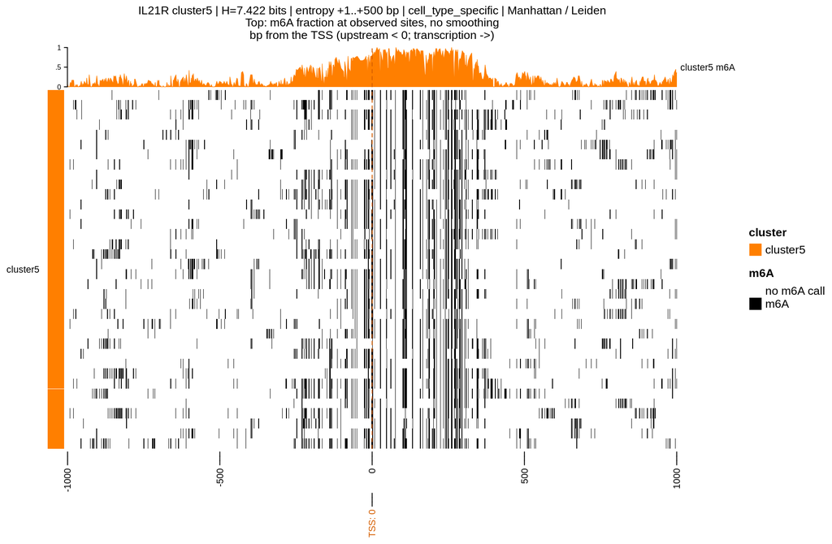

```r
plot_selected_cluster(selected_data$IL21R, "m6a", 5L)
```

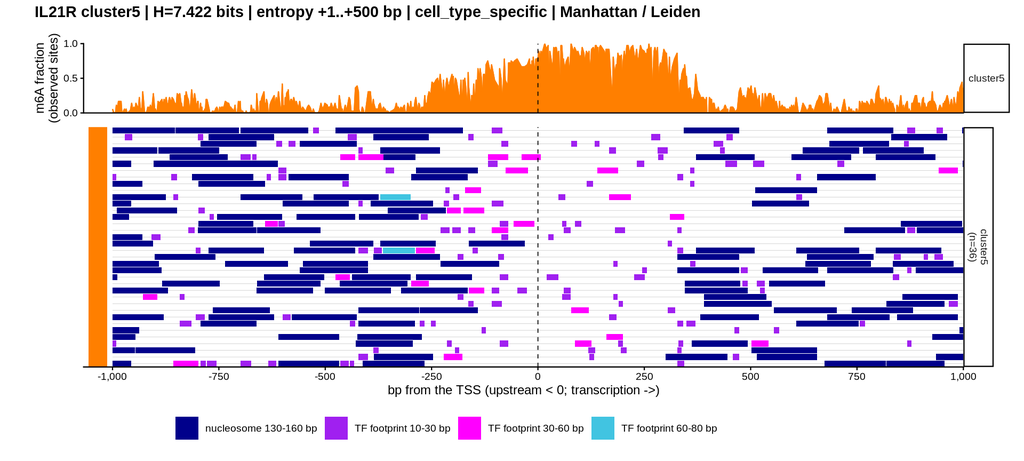

```r
plot_selected_cluster(selected_data$IL21R, "footprints", 6L)
```

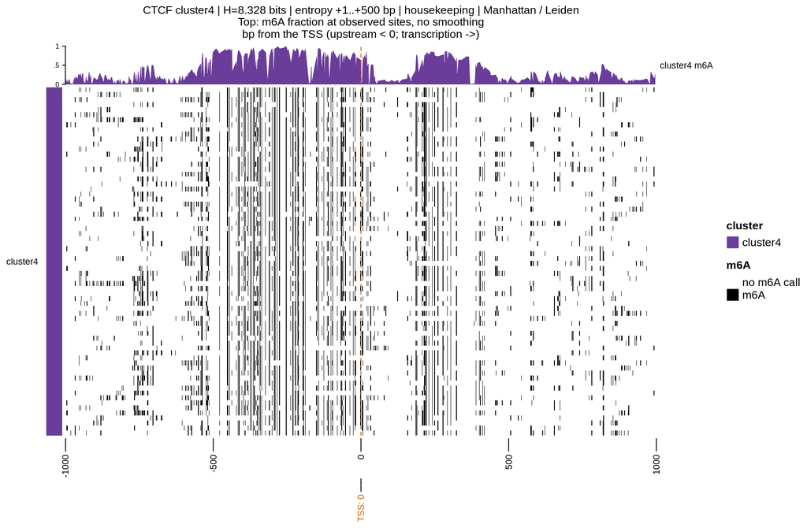

```r
plot_selected_cluster(selected_data$CTCF, "m6a", 7L)
```

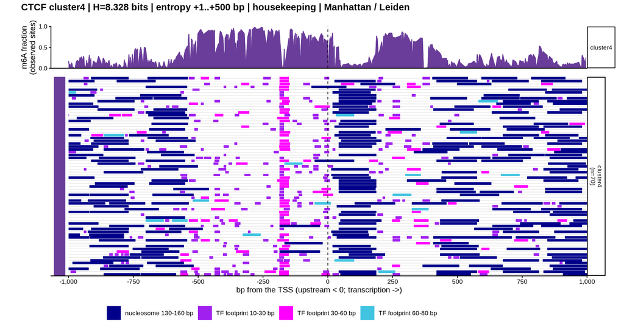

```r
plot_selected_cluster(selected_data$CTCF, "footprints", 8L)
```

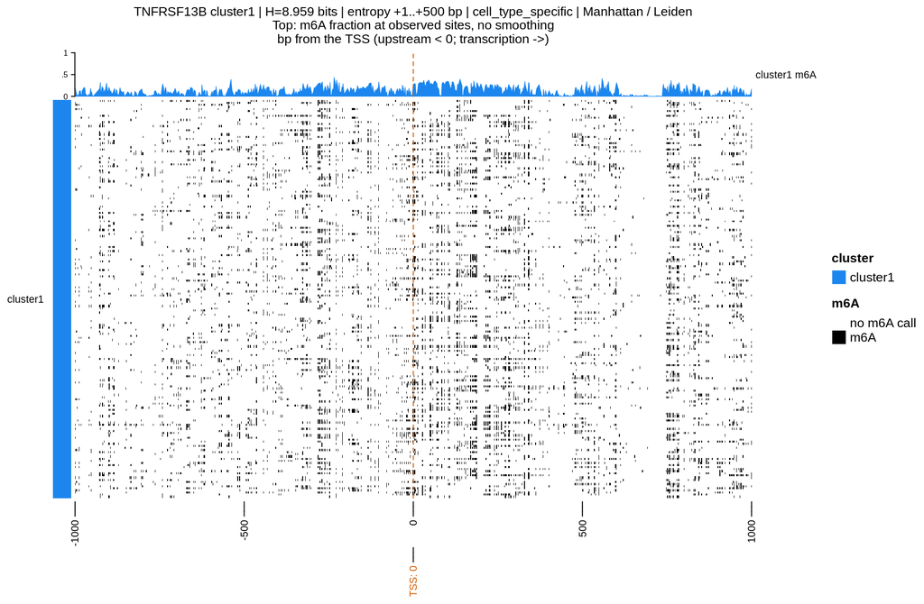

```r
plot_selected_cluster(selected_data$TNFRSF13B, "m6a", 9L)
```

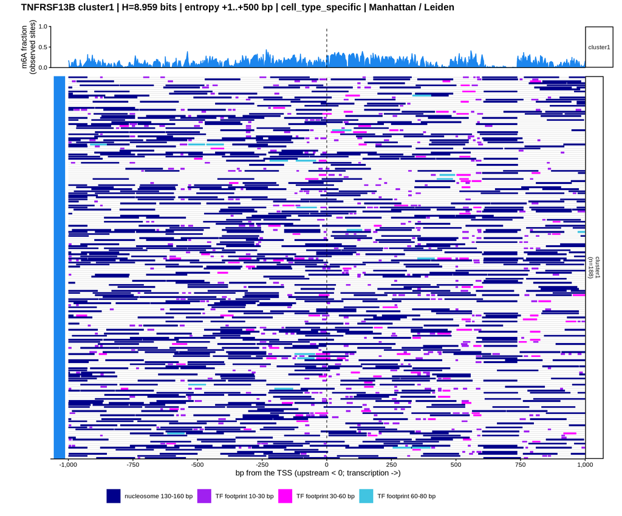

```r
plot_selected_cluster(selected_data$TNFRSF13B, "footprints", 10L)
```

### 6. gene ranking by raw and normalized nucleosome entropy

Each row is one gene, ranked from highest entropy at the top to lowest at the bottom. Left: raw entropy in bits, right: normalized entropy $H / \log_2 500$. The two panels have the same gene order, because every gene uses the same 500 bases

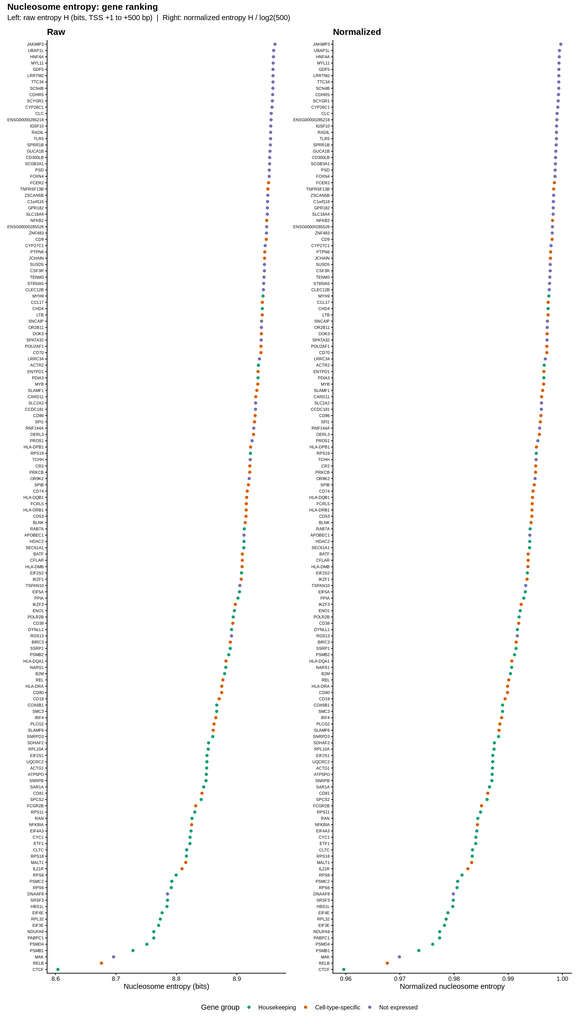

```r
p <- plot_ranking_pair(genes, NUCLEOSOME_SPEC)
save_pdf(p, "11_nucleosome_entropy_ranking.pdf", 12, ranking_height(genes))
p
```

# Molecule-cluster entropy

this cluster level entropy is calculated using each gene’s cluster proportions and the number of reads in the cluster

**low entropy** genes have fibers concentrated in one or a few clusters, whereas **high entropy** genes have fibers spread across many clusters. This is a per-gene measure of how evenly a gene’s fibers are split among that gene’s original Leiden clusters of single-molecule promoter patterns. It is calculated by `code/entropy/molecule_cluster/molecule_cluster_entropy.R`

Input files:

- Genes: `code/pausing/PolII/example_gene_list.tsv`
- Cluster assignments: `LCL_project/pausing/PolII/recurrent_patterns/tables/<group>/<gene>_read_clusters.tsv`, one row per fiber with the original per-gene Leiden `cluster` label. These come from the full-span promoter reads(TSS +/-1000 bp)
- reads: `LCL_project/pausing/PolII/read_features/tables/read_features.tsv.gz`

**Steps**

1. A gene is valid only if it has $>$ 20 assigned reads and $>$ 1 cluster. For gene $g$ with $K$ observed clusters, let $n_k$ be the number of assigned fibers in cluster $k$ and $N = \sum_k n_k$. The cluster proportions are
   $$p_k = \frac{n_k}{N}.$$
2. Shannon entropy (bits), normalized entropy and effective number of states:

   $$H = -\sum_{k=1}^{K} p_k \log_2 p_k,
   \qquad
   H_{\text{norm}} = \frac{H}{\log_2 K}\ (K \ge 2), \qquad
   D = 2^{H}.$$

   With $K = 1$, $H = 0$, $D = 1$ and $H_{\text{norm}}$ is NA
   - **Normalized entropy** $H_{\text{norm}}$ divides $H$ by the largest entropy possible with $K$ clusters. That maximum, $\log_2 K$, is reached only when every cluster holds the same share of fibers ($p_k = 1/K$). $H_{\text{norm}}$ therefore runs from 0 (all fibers in one cluster) to 1 (all clusters equal in size), and says how evenly the fibers are spread over the clusters the gene has, regardless of how many there are. It is NA for $K = 1$ because $\log_2 1 = 0$, and with one cluster there is no evenness to measure
   - **Effective number of states** $D$ turns $H$ back into a count of clusters: it is the number of equally sized clusters that would give the same entropy, because $K$ equal clusters have $H = \log_2 K$, so $2^H = K$
     - For example, a gene with 4 clusters holding 70%, 10%, 10% and 10% of its fibers has $H = 1.36$ bits and $D = 2.6$: it behaves like 2.6 equally used states, not 4, because one cluster dominates. $D$ is always between 1 and $K$
3. Raw $H$ grows with both the number of clusters and their evenness, whereas $H_{\text{norm}}$ measures evenness only, relative to that gene’s $K$.

Output tables(`LCL_project/entropy/molecule_cluster_entropy/tables/`):

- `gene_molecule_cluster_entropy.tsv` (one row per gene)
- `cluster_proportions.tsv` ($n_k$, $p_k$)
- `gene_group_summary.tsv` and `gene_group_tests.tsv` (KW + plus pairwise Wilcoxon tests BH-adjusted across the three gene groups)
  - *Kruskal-Wallis (KW)*: whether the three gene groups have the same distribution, using one value per gene. It works on ranks and does not assume normal distribution, and a small p-value means at least one group differs, without saying which
  - *Pairwise Wilcoxon rank-sum*: compares two groups at a time (housekeeping vs cell-type-specific, housekeeping vs not expressed, cell-type-specific vs not expressed) to find which groups differ

```r
MOLECULE_OUT <- Sys.getenv("MOLECULE_ENTROPY_OUT",
  file.path(PROJECT, "LCL_project/entropy/molecule_cluster_entropy"))
MOLECULE_TABLES <- file.path(MOLECULE_OUT, "tables")
MOLECULE_FIGURES <- file.path(MOLECULE_OUT, "figures")
dir.create(MOLECULE_FIGURES, recursive = TRUE, showWarnings = FALSE)
```

1. `gene_molecule_cluster_entropy.tsv`
- One row per gene (150 genes): `n_clusters` is $K$, `n_assigned_reads` is $N$, and `shannon_entropy_bits`, `normalized_entropy` and `effective_states` are $H$, $H_{\text{norm}}$ and $D$
- `status` is `valid` for 148 genes; SLC44A4 is `no_valid_assignments` because it has no saved reads, and HLA-DMA is `below_min_reads_or_clusters` (5 reads, one cluster). Only valid genes are used in the summaries, tests and figures

```r
molecule_genes <- fread(file.path(MOLECULE_TABLES, "gene_molecule_cluster_entropy.tsv"))
knitr::kable(head(molecule_genes[, .(gene_name, group, n_assigned_reads, n_clusters,
  shannon_entropy_bits, normalized_entropy, effective_states, status)]), digits = 3)
```

| gene_name | group | n_assigned_reads | n_clusters | shannon_entropy_bits | normalized_entropy | effective_states | status |
| --- | --- | --- | --- | --- | --- | --- | --- |
| CD74 | cell_type_specific | 453 | 4 | 1.998 | 0.999 | 3.994 | valid |
| HLA-DRA | cell_type_specific | 101 | 4 | 1.956 | 0.978 | 3.880 | valid |
| HLA-DRB1 | cell_type_specific | 134 | 3 | 1.580 | 0.997 | 2.990 | valid |
| HLA-DQA1 | cell_type_specific | 205 | 4 | 1.990 | 0.995 | 3.972 | valid |
| IRF4 | cell_type_specific | 537 | 7 | 2.781 | 0.991 | 6.875 | valid |
| HLA-DPB1 | cell_type_specific | 61 | 4 | 1.818 | 0.909 | 3.526 | valid |

2. `cluster_proportions.tsv`
- One row per gene and cluster: `n_reads` is $n_k$, the assigned fibers in that cluster, and `proportion` is $p_k = n_k / N$, which sums to 1 within each gene

```r
molecule_proportions <- fread(file.path(MOLECULE_TABLES, "cluster_proportions.tsv"))
knitr::kable(head(molecule_proportions[, .(gene_name, group, cluster, n_reads, proportion)]), digits = 3)
```

| gene_name | group | cluster | n_reads | proportion |
| --- | --- | --- | --- | --- |
| CD74 | cell_type_specific | cluster2 | 118 | 0.260 |
| CD74 | cell_type_specific | cluster3 | 108 | 0.238 |
| CD74 | cell_type_specific | cluster4 | 106 | 0.234 |
| CD74 | cell_type_specific | cluster1 | 121 | 0.267 |
| HLA-DRA | cell_type_specific | cluster1 | 32 | 0.317 |
| HLA-DRA | cell_type_specific | cluster3 | 24 | 0.238 |

3. `gene_group_summary.tsv`
- One row per gene group, over its valid genes: the median and quartiles of $H$, and the medians of $H_{\text{norm}}$, $D$, the number of clusters and the number of assigned fibers

```r
molecule_group_summary <- fread(file.path(MOLECULE_TABLES, "gene_group_summary.tsv"))
knitr::kable(molecule_group_summary[, .(group, n_valid_genes, median_shannon_entropy,
  median_normalized_entropy, median_effective_states, median_cluster_number)], digits = 3)
```

| group | n_valid_genes | median_shannon_entropy | median_normalized_entropy | median_effective_states | median_cluster_number |
| --- | --- | --- | --- | --- | --- |
| cell_type_specific | 49 | 2.256 | 0.958 | 4.778 | 5 |
| housekeeping | 50 | 2.449 | 0.973 | 5.461 | 6 |
| not_expressed | 49 | 2.257 | 0.972 | 4.781 | 5 |

4. `gene_group_tests.tsv`
- For each of $H$, $H_{\text{norm}}$ and $D$: a Kruskal-Wallis test across the three gene groups, then the three pairwise Wilcoxon rank-sum tests with BH-adjusted p-values (`p_adjusted_BH`, adjusted within each metric)

```r
molecule_group_tests <- fread(file.path(MOLECULE_TABLES, "gene_group_tests.tsv"))
knitr::kable(molecule_group_tests, digits = 4)
```

| metric | test | comparison | p_value | p_adjusted_BH |
| --- | --- | --- | --- | --- |
| shannon_entropy_bits | Kruskal-Wallis | all groups | 0.0066 | NA |
| shannon_entropy_bits | Wilcoxon rank-sum | cell_type_specific vs housekeeping | 0.0219 | 0.0329 |
| shannon_entropy_bits | Wilcoxon rank-sum | cell_type_specific vs not_expressed | 0.2996 | 0.2996 |
| shannon_entropy_bits | Wilcoxon rank-sum | housekeeping vs not_expressed | 0.0033 | 0.0098 |
| normalized_entropy | Kruskal-Wallis | all groups | 0.2354 | NA |
| normalized_entropy | Wilcoxon rank-sum | cell_type_specific vs housekeeping | 0.1966 | 0.2949 |
| normalized_entropy | Wilcoxon rank-sum | cell_type_specific vs not_expressed | 0.1266 | 0.2949 |
| normalized_entropy | Wilcoxon rank-sum | housekeeping vs not_expressed | 0.5543 | 0.5543 |
| effective_states | Kruskal-Wallis | all groups | 0.0066 | NA |
| effective_states | Wilcoxon rank-sum | cell_type_specific vs housekeeping | 0.0219 | 0.0329 |
| effective_states | Wilcoxon rank-sum | cell_type_specific vs not_expressed | 0.2996 | 0.2996 |
| effective_states | Wilcoxon rank-sum | housekeeping vs not_expressed | 0.0033 | 0.0098 |

```r
stopifnot(!anyDuplicated(molecule_genes$gene_name))
molecule_valid <- molecule_genes[status == "valid" & is.finite(shannon_entropy_bits)]
stopifnot(nrow(molecule_valid) > 0L, all(molecule_valid$group %in% GROUPS))
molecule_valid[, group := factor(group, GROUPS)]
save_molecule_pdf <- function(p, name, width = 9, height = 6)
  save_figure(p, file.path(MOLECULE_FIGURES, name), width = width, height = height,
              device = "pdf", useDingbats = FALSE)
# Promoter features (motif, +1 start, short footprints) are the nucleosome-section ones
MOLECULE_SPEC <- list(name = "Molecule-cluster entropy",
  raw = "shannon_entropy_bits", raw_label = "Molecule-cluster Shannon entropy (bits)", raw_max = NULL,
  normalized = "normalized_entropy", normalized_label = "Normalized molecule-cluster entropy",
  normalized_max = 1,
  subtitle = "Left: raw Shannon entropy H (bits)  |  Right: normalized entropy H / log2(K), K = number of clusters")
molecule_metrics <- molecule_valid[, .(gene_name, shannon_entropy_bits, normalized_entropy)]
molecule_plot <- merge(molecule_metrics, genes[, .(gene_name, group, puffin_motif, plus1_start_mean_bp)],
                       by = "gene_name")
stopifnot(setequal(molecule_plot$gene_name, molecule_valid$gene_name),
          setequal(molecule_plot$gene_name, genes$gene_name))
molecule_fp <- merge(fp_genes[, .(gene_name, group, footprint_class, fraction_with_footprint)],
                     molecule_metrics, by = "gene_name")
```

### 1. molecule-cluster entropy by gene group

Each point is one gene, black diamond marks the median. Shannon entropy (bits) is the “how unpredictable is a fiber’s cluster” score: 0 means all of a gene’s fibers are in one cluster; higher means more clusters and/or more even clusters. Normalized entropy divides it by the maximum for the gene’s number of clusters, $\log_2 K$, and runs from 0 to 1 (1 = every cluster holds the same share). Left: raw entropy, right: normalized entropy

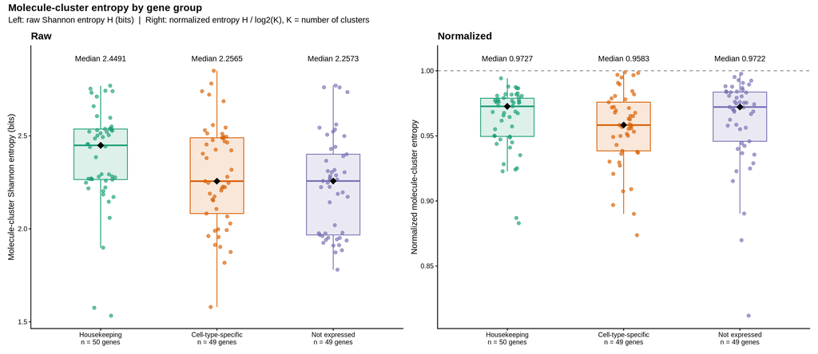

```r
p <- plot_group_pair(molecule_plot, MOLECULE_SPEC)
save_molecule_pdf(p, "01_gene_group_entropy.pdf", 15, 6.5)
p
```

### 2. molecule-cluster entropy by Puffin dominant motif

Each point is one gene, grouped by its Puffin dominant motif. Motifs are ordered by median raw entropy. Left: raw entropy, right: normalized entropy

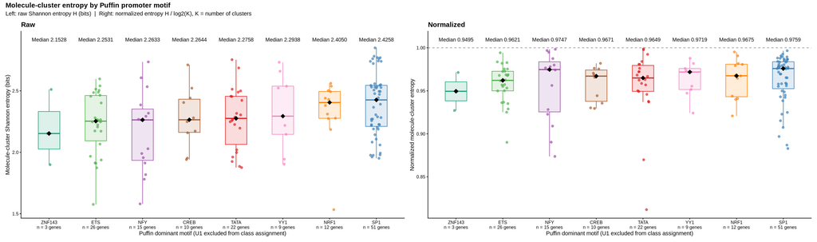

```r
p <- plot_motif_pair(molecule_plot, MOLECULE_SPEC)
save_molecule_pdf(p, "02_entropy_by_puffin_motif.pdf", 22, 6.5)
p
```

### 3. molecule-cluster entropy and +1 nucleosome start position

Each point is one gene. The +1 coordinate is the same as in the nucleosome section (mean of the per-fiber first nucleosome starts at +1..+299 bp). Left: raw entropy, right: normalized entropy

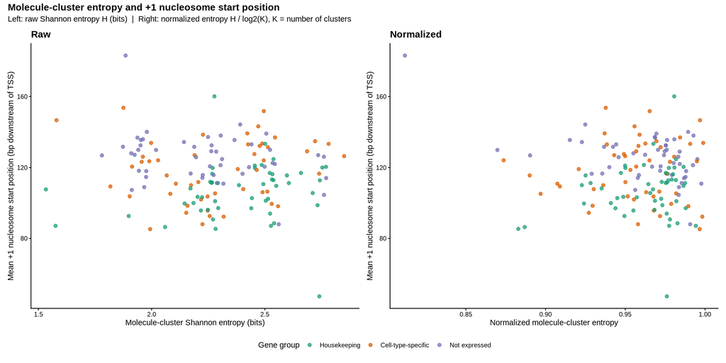

```r
p <- plot_plus1_pair(molecule_plot, MOLECULE_SPEC)
save_molecule_pdf(p, "03_entropy_vs_plus1_start.pdf", 14, 7)
p
```

### 4. molecule-cluster entropy and footprint presence at promoters

Footprint fractions are the nucleosome-section ones (fibers with a 10-<30, 30-<60 or 60-80 bp footprint overlapping TSS -100..+100 bp). Left: raw entropy, right: normalized entropy

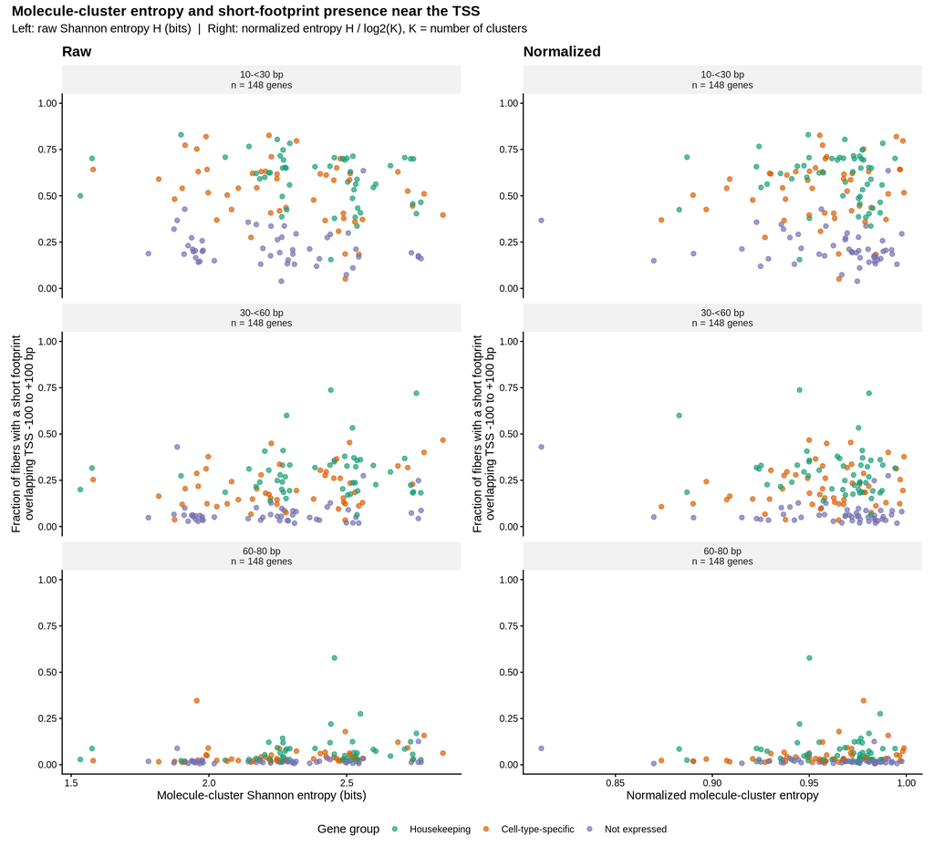

```r
p <- plot_footprint_pair(molecule_fp, MOLECULE_SPEC)
save_molecule_pdf(p, "04_entropy_vs_short_footprints.pdf", 12, 11)
p
```

### 5. gene ranking by raw and normalized molecule-cluster entropy

Each row is one gene, ranked from highest entropy at the top to lowest at the bottom; each panel has its own gene order. Left: raw Shannon entropy (number of clusters and evenness), right: normalized entropy (evenness only)

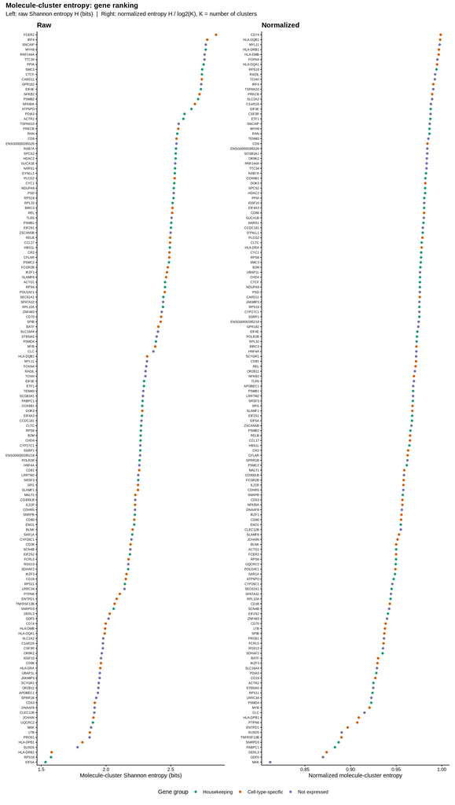

```r
p <- plot_ranking_pair(molecule_plot, MOLECULE_SPEC)
save_molecule_pdf(p, "05_entropy_ranking.pdf", 12, ranking_height(molecule_plot))
p
```

Full ranking by normalized molecule-cluster entropy, highest first. `Largest cluster` is the share of the gene’s fibers in its largest cluster

```r
largest_cluster <- molecule_proportions[, .(largest_cluster = max(proportion)), by = gene_name]
normalized_ranking <- merge(molecule_valid, largest_cluster, by = "gene_name")[
  order(-normalized_entropy, gene_name)]
normalized_ranking[, rank := seq_len(.N)]
knitr::kable(normalized_ranking[, .(rank, gene_name, group = GROUP_LABELS[as.character(group)], n_clusters,
  n_assigned_reads, normalized_entropy, shannon_entropy_bits, largest_cluster)],
  digits = c(0, 0, 0, 0, 0, 3, 2, 2), row.names = FALSE,
  col.names = c("Rank", "Gene", "Gene group", "Clusters", "Assigned fibers", "Normalized entropy",
                "Shannon entropy (bits)", "Largest cluster"),
  caption = "Genes ranked by normalized molecule-cluster entropy.")
```

Genes ranked by normalized molecule-cluster entropy.

| Rank | Gene | Gene group | Clusters | Assigned fibers | Normalized entropy | Shannon entropy (bits) | Largest cluster |
| --- | --- | --- | --- | --- | --- | --- | --- |
| 1 | CD74 | Cell-type-specific | 4 | 453 | 0.999 | 2.00 | 0.27 |
| 2 | HLA-DQB1 | Cell-type-specific | 5 | 216 | 0.998 | 2.32 | 0.22 |
| 3 | MYL11 | Not expressed | 5 | 384 | 0.998 | 2.32 | 0.22 |
| 4 | HLA-DRB1 | Cell-type-specific | 3 | 134 | 0.997 | 1.58 | 0.37 |
| 5 | HLA-DMB | Cell-type-specific | 4 | 81 | 0.997 | 1.99 | 0.27 |
| 6 | FOXN4 | Not expressed | 5 | 554 | 0.995 | 2.31 | 0.24 |
| 7 | HLA-DQA1 | Cell-type-specific | 4 | 205 | 0.995 | 1.99 | 0.30 |
| 8 | RPS18 | Housekeeping | 3 | 57 | 0.994 | 1.58 | 0.39 |
| 9 | RADIL | Not expressed | 5 | 481 | 0.993 | 2.31 | 0.25 |
| 10 | TCHH | Not expressed | 5 | 568 | 0.992 | 2.30 | 0.26 |
| 11 | IRF4 | Cell-type-specific | 7 | 537 | 0.991 | 2.78 | 0.20 |
| 12 | TSPAN10 | Not expressed | 6 | 499 | 0.991 | 2.56 | 0.21 |
| 13 | PRKCB | Cell-type-specific | 6 | 527 | 0.990 | 2.56 | 0.22 |
| 14 | SLC2A2 | Not expressed | 4 | 711 | 0.989 | 1.98 | 0.32 |
| 15 | C1orf116 | Not expressed | 4 | 602 | 0.988 | 1.98 | 0.32 |
| 16 | EIF3E | Housekeeping | 5 | 632 | 0.988 | 2.29 | 0.25 |
| 17 | CSF3R | Not expressed | 4 | 498 | 0.988 | 1.98 | 0.33 |
| 18 | ETF1 | Housekeeping | 5 | 521 | 0.988 | 2.29 | 0.24 |
| 19 | SNCAIP | Not expressed | 7 | 667 | 0.987 | 2.77 | 0.18 |
| 20 | MYH9 | Housekeeping | 7 | 439 | 0.987 | 2.77 | 0.19 |
| 21 | RAN | Housekeeping | 6 | 468 | 0.987 | 2.55 | 0.21 |
| 22 | TENM3 | Not expressed | 5 | 608 | 0.985 | 2.29 | 0.26 |
| 23 | CD9 | Cell-type-specific | 6 | 474 | 0.984 | 2.54 | 0.24 |
| 24 | ENSG00000285526 | Not expressed | 6 | 424 | 0.984 | 2.54 | 0.22 |
| 25 | SCGB3A1 | Not expressed | 5 | 458 | 0.984 | 2.29 | 0.28 |
| 26 | OR9K2 | Not expressed | 4 | 654 | 0.984 | 1.97 | 0.31 |
| 27 | RNF144A | Not expressed | 7 | 540 | 0.983 | 2.76 | 0.19 |
| 28 | TTC34 | Not expressed | 7 | 366 | 0.983 | 2.76 | 0.20 |
| 29 | RAB7A | Housekeeping | 6 | 582 | 0.983 | 2.54 | 0.19 |
| 30 | COX6B1 | Housekeeping | 5 | 482 | 0.982 | 2.28 | 0.26 |

[output cut: 118 more lines]

### 6. cluster entropy by the number of clusters

entropy is mostly determined by the total number of clusters

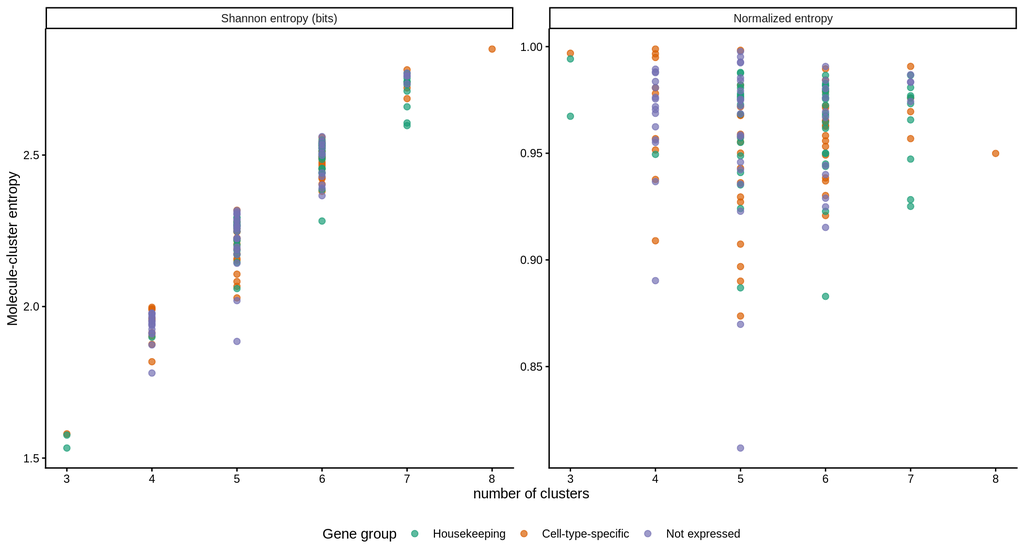

```r
plot_entropy_vs_cluster_number <- function(d) {
  long <- melt(d, id.vars = c("gene_name", "group", "n_clusters", "n_assigned_reads"),
               measure.vars = c("shannon_entropy_bits", "normalized_entropy"),
               variable.name = "metric", value.name = "entropy")
  long <- long[is.finite(entropy)]
  ggplot(long, aes(n_clusters, entropy, colour = group)) + geom_point(alpha = .7, size = 2) +
    facet_wrap(~ metric, scales = "free_y", labeller = as_labeller(c(
      shannon_entropy_bits = "Shannon entropy (bits)", normalized_entropy = "Normalized entropy"))) +
    scale_colour_manual(values = GROUP_COLORS, labels = GROUP_LABELS, name = "Gene group") +
    labs(x = "number of clusters", y = "Molecule-cluster entropy") +
    theme_fiberseq(base_size = 11) + theme(legend.position = "bottom")
}
p <- plot_entropy_vs_cluster_number(molecule_valid)
save_molecule_pdf(p, "06_entropy_vs_cluster_number.pdf", 11, 6)
p
```

Distribution of molecule-cluster Shannon entropy over all valid genes, all gene groups pooled; bin width 0.05 bits

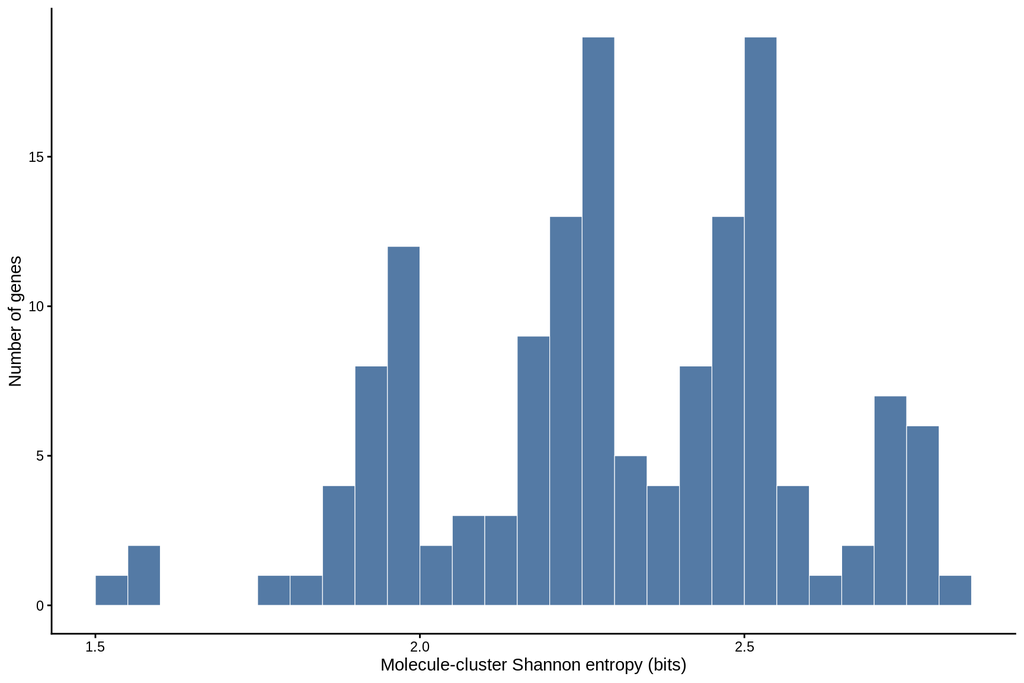

```r
plot_shannon_histogram <- function(d) {
  ggplot(d[is.finite(shannon_entropy_bits)], aes(shannon_entropy_bits)) +
    geom_histogram(binwidth = .05, boundary = 0, fill = "#547AA5", colour = "white", linewidth = .2) +
    labs(x = "Molecule-cluster Shannon entropy (bits)", y = "Number of genes") +
    theme_fiberseq(base_size = 11)
}
p <- plot_shannon_histogram(molecule_valid)
save_molecule_pdf(p, "07_shannon_entropy_histogram.pdf")
p
```

Number of original Leiden clusters per gene in each gene group, one gene per count

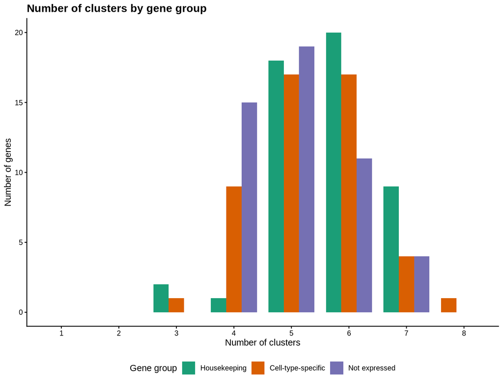

```r
plot_cluster_number_by_group <- function(d) {
  z <- d[, .N, by = .(group, n_clusters)]
  ggplot(z, aes(factor(n_clusters, levels = seq_len(max(n_clusters))), N, fill = group)) +
    geom_col(position = position_dodge(preserve = "single"), width = .8) +
    scale_x_discrete(drop = FALSE) +
    scale_fill_manual(values = GROUP_COLORS, breaks = GROUPS, labels = GROUP_LABELS, name = "Gene group") +
    labs(x = "Number of clusters", y = "Number of genes", title = "Number of clusters by gene group") +
    theme(legend.position = "bottom")
}
p <- plot_cluster_number_by_group(molecule_valid)
save_molecule_pdf(p, "08_cluster_number_by_group.pdf", 8.5, 6.5)
p
```

# Gini-Simpson diversity of molecule clusters

Gini-Simpson diversity is another to summarize how a gene’s fibers are split among its own Leiden m6A clusters. It uses the same cluster proportions as molecule-cluster entropy, but asks a simpler question:

- **if two fibers are drawn at random from the same promoter, how likely are they to be in different clusters?**

It is calculated by `code/entropy/gini_simpson_molecule_cluster/simpson_functions.R`

The approach is adapted from de Langen et al. (Pol II atlas), who use Gini-Simpson diversity per consensus peak across altas of cancer and normal tissues

Input:

- Cluster counts and proportions: `LCL_project/entropy/molecule_cluster_entropy/tables/cluster_proportions.tsv` and `gene_molecule_cluster_entropy.tsv`
- cluster assignments:`LCL_project/pausing/PolII/recurrent_patterns/tables/<group>/<gene>_read_clusters.tsv`
- Per-read chromatin features (+1 nucleosome, TSS occupancy, m6A): `LCL_project/pausing/PolII/read_features/tables/read_features.tsv.gz`
- FiberHMM v1 footprints: `LCL_Fiber_seq/FiberHMM/merged/<sample>/joint_trained_results/<sample>_<chr>_fp.bed.gz`

**Steps**

1. Take each gene’s cluster counts $n_k$ and proportions $p_k = n_k / N$. Only genes valid for molecule-cluster entropy ($>$ 20 assigned reads and $>$ 1 cluster) get a diversity value; the others are NA
2. Gini-Simpson diversity, normalized diversity and inverse Simpson:

   $$G = 1 - \sum_{k=1}^{K} p_k^2, \qquad
   G_{\text{norm}} = \frac{G}{1 - 1/K}\ (K \ge 2), \qquad
   D_2 = \frac{1}{\sum_{k=1}^{K} p_k^2}.$$
   - $\sum_k p_k^2$ is the probability that two fibers drawn at random (with replacement) are in the same cluster, so $G$ is the probability that they are in different clusters
   - $G = 0$ when all reads are in one cluster; the largest possible value for $K$ clusters is $1 - 1/K$, reached when all clusters are equal
   - $G_{\text{norm}}$ divides out that ceiling and measures evenness only (NA for $K = 1$)
   - $D_2$ is the number of equally sized clusters that would give the same $G$
3. For each read, compute promoter chromatin features: the fraction of fibers with a +1 nucleosome and its mean start position (+1..+299 bp), the fraction of fibers with a nucleosome over the TSS, the mean m6A rate in -500..-201, -200..+200 and +201..+500 bp, and footprint fractions
- a read has a footprint of a size class ([40,60), [60,80] or [10,80] bp) in a window (-100..+100 or 0..+300 bp) if at least 50% of the footprint’s length lies in the window, the denominator is the reads spanning the whole window
5. Correlate $G$ with each of the 12 features (Spearman), pooled and within each group

Outputs

```r
GINI_OUT <- file.path(PROJECT, "LCL_project/entropy/gini_simpson_molecule_cluster")
GINI_TABLES <- file.path(GINI_OUT, "tables")
```

1. `gini_simpson_molecule_cluster.tsv`
- One row per gene: `n_fibers_assigned` ($N$), `n_clusters` ($K$), `gini_simpson` ($G$), `normalized_gini_simpson` ($G_{\text{norm}}$), `inverse_simpson` ($D_2$) and `shannon_entropy`
- `dominant_cluster_id` / `dominant_cluster_fraction` are the largest cluster and its share of fibers

```r
gini_genes <- fread(file.path(GINI_TABLES, "gini_simpson_molecule_cluster.tsv"))
knitr::kable(head(gini_genes[, .(gene_name, gene_group, n_fibers_assigned, n_clusters,
  dominant_cluster_fraction, gini_simpson, normalized_gini_simpson, inverse_simpson)]), digits = 3)
```

| gene_name | gene_group | n_fibers_assigned | n_clusters | dominant_cluster_fraction | gini_simpson | normalized_gini_simpson | inverse_simpson |
| --- | --- | --- | --- | --- | --- | --- | --- |
| ACTG1 | housekeeping | 201 | 6 | 0.289 | 0.803 | 0.964 | 5.077 |
| ACTR2 | housekeeping | 591 | 7 | 0.288 | 0.817 | 0.953 | 5.473 |
| APOBEC1 | not_expressed | 462 | 4 | 0.323 | 0.730 | 0.973 | 3.701 |
| ATP5PO | housekeeping | 637 | 7 | 0.303 | 0.823 | 0.960 | 5.637 |
| B2M | housekeeping | 377 | 5 | 0.265 | 0.785 | 0.981 | 4.655 |
| BATF | cell_type_specific | 576 | 6 | 0.267 | 0.800 | 0.960 | 5.004 |

2. `cluster_proportions.tsv`
- One row per promoter and cluster: `n_reads` ($n_k$) and `proportion` ($p_k$), the same counts as the molecule-cluster table, re-checked against the assignment files
- `abundance_rank` orders a promoter’s clusters by size (1 = largest); it is not a shared cluster identity across genes

```r
gini_proportions <- fread(file.path(GINI_TABLES, "cluster_proportions.tsv"))
knitr::kable(head(gini_proportions[, .(gene_name, gene_group, cluster, n_reads, proportion, abundance_rank)]), digits = 3)
```

| gene_name | gene_group | cluster | n_reads | proportion | abundance_rank |
| --- | --- | --- | --- | --- | --- |
| ACTG1 | housekeeping | cluster1 | 58 | 0.289 | 1 |
| ACTG1 | housekeeping | cluster2 | 44 | 0.219 | 2 |
| ACTG1 | housekeeping | cluster3 | 35 | 0.174 | 3 |
| ACTG1 | housekeeping | cluster4 | 28 | 0.139 | 4 |
| ACTG1 | housekeeping | cluster5 | 18 | 0.090 | 5 |
| ACTG1 | housekeeping | cluster6 | 18 | 0.090 | 6 |

3. `simpson_group_summary.tsv`
- One row per gene group, over genes with a finite $G$: median and quartiles of $G$, and medians of $G_{\text{norm}}$, $D_2$, cluster number and assigned fibers

```r
gini_summary <- fread(file.path(GINI_TABLES, "simpson_group_summary.tsv"))
gini_median <- function(group, column) sprintf("%.3f", gini_summary[gene_group == (group)][[column]])
knitr::kable(gini_summary, digits = 3)
```

| gene_group | n_valid_genes | median_gini_simpson | q25 | q75 | iqr | median_normalized_gini_simpson | median_inverse_simpson | median_cluster_count | median_assigned_fibers |
| --- | --- | --- | --- | --- | --- | --- | --- | --- | --- |
| cell_type_specific | 49 | 0.782 | 0.748 | 0.812 | 0.064 | 0.973 | 4.596 | 5 | 518 |
| housekeeping | 50 | 0.804 | 0.783 | 0.821 | 0.038 | 0.980 | 5.092 | 6 | 544 |
| not_expressed | 49 | 0.782 | 0.737 | 0.798 | 0.061 | 0.978 | 4.579 | 5 | 558 |

4. `simpson_group_tests.tsv`
- For $G$ and $G_{\text{norm}}$: a Kruskal-Wallis test across the three gene groups and the three pairwise Wilcoxon rank-sum tests, BH-adjusted within each metric (same tests as for molecule-cluster entropy)

```r
gini_tests <- fread(file.path(GINI_TABLES, "simpson_group_tests.tsv"))
gini_kw <- function(m) signif(gini_tests[metric == m & test == "Kruskal-Wallis", p_value], 2)
knitr::kable(gini_tests, digits = 4)
```

| metric | test | comparison | p_value | p_adjusted_BH |
| --- | --- | --- | --- | --- |
| gini_simpson | Kruskal-Wallis | all groups | 0.0086 | NA |
| gini_simpson | Wilcoxon rank-sum | housekeeping vs cell_type_specific | 0.0263 | 0.0394 |
| gini_simpson | Wilcoxon rank-sum | housekeeping vs not_expressed | 0.0042 | 0.0125 |
| gini_simpson | Wilcoxon rank-sum | cell_type_specific vs not_expressed | 0.3062 | 0.3062 |
| normalized_gini_simpson | Kruskal-Wallis | all groups | 0.3064 | NA |
| normalized_gini_simpson | Wilcoxon rank-sum | housekeeping vs cell_type_specific | 0.1351 | 0.3746 |
| normalized_gini_simpson | Wilcoxon rank-sum | housekeeping vs not_expressed | 1.0000 | 1.0000 |
| normalized_gini_simpson | Wilcoxon rank-sum | cell_type_specific vs not_expressed | 0.2497 | 0.3746 |

5. `chromatin_features.tsv`
- One row per promoter: the diversity columns of table 1 joined to the 12 chromatin features of the steps below (+1 nucleosome fraction and mean start, TSS occlusion, three m6A windows, six short-footprint fractions), all from the same assigned fibers
- The `n_*` columns are the fibers each feature is based on

```r
gini_features <- fread(file.path(GINI_TABLES, "chromatin_features.tsv"))
knitr::kable(head(gini_features[, .(gene_name, gene_group, gini_simpson, plus1_fraction, plus1_start_mean,
  tss_occlusion_fraction, m6a_tss_centered, fp10_80_tss)]), digits = 3)
```

| gene_name | gene_group | gini_simpson | plus1_fraction | plus1_start_mean | tss_occlusion_fraction | m6a_tss_centered | fp10_80_tss |
| --- | --- | --- | --- | --- | --- | --- | --- |
| CFLAR | cell_type_specific | 0.812 | 0.581 | 133.519 | 0.163 | 0.111 | 0.445 |
| CD38 | cell_type_specific | 0.766 | 0.610 | 126.958 | 0.140 | 0.251 | 0.733 |
| PSMB1 | housekeeping | 0.816 | 0.631 | 101.283 | 0.003 | 0.268 | 0.663 |
| CD9 | cell_type_specific | 0.823 | 0.624 | 136.966 | 0.291 | 0.128 | 0.257 |
| CD74 | cell_type_specific | 0.749 | 0.492 | 133.865 | 0.084 | 0.376 | 0.680 |
| BIRC3 | cell_type_specific | 0.816 | 0.492 | 131.464 | 0.050 | 0.388 | 0.713 |

6. `short_footprint_features.tsv`
- Six rows per promoter, one per size class × window: `n_eligible_fibers` (fibers spanning the whole window, the denominator), `n_fibers_with_footprint` (those with a qualifying footprint) and their ratio `fraction`

```r
gini_short_fp <- fread(file.path(GINI_TABLES, "short_footprint_features.tsv"))
knitr::kable(head(gini_short_fp[, .(gene_name, size_class, window, window_start, window_end,
  n_eligible_fibers, n_fibers_with_footprint, fraction, status)]), digits = 3)
```

| gene_name | size_class | window | window_start | window_end | n_eligible_fibers | n_fibers_with_footprint | fraction | status |
| --- | --- | --- | --- | --- | --- | --- | --- | --- |
| ACTG1 | fp40_60 | tss | -100 | 100 | 201 | 41 | 0.204 | complete |
| ACTG1 | fp60_80 | tss | -100 | 100 | 201 | 116 | 0.577 | complete |
| ACTG1 | fp10_80 | tss | -100 | 100 | 201 | 163 | 0.811 | complete |
| ACTG1 | fp40_60 | downstream | 0 | 300 | 201 | 35 | 0.174 | complete |
| ACTG1 | fp60_80 | downstream | 0 | 300 | 201 | 7 | 0.035 | complete |
| ACTG1 | fp10_80 | downstream | 0 | 300 | 201 | 100 | 0.498 | complete |

7. `simpson_feature_associations.tsv`
- One row per feature × stratum (`all` = pooled, or one gene group): number of promoters, and the Spearman $\rho$ between $G$ and the feature (no p-values)

```r
gini_associations <- fread(file.path(GINI_TABLES, "simpson_feature_associations.tsv"))
knitr::kable(gini_associations[stratum == "all"], digits = 4)
```

| feature | stratum | n_promoters | spearman_rho |
| --- | --- | --- | --- |
| plus1_fraction | all | 148 | 0.2954 |
| plus1_start_mean | all | 148 | -0.0482 |
| tss_occlusion_fraction | all | 148 | -0.2171 |
| m6a_promoter_proximal | all | 148 | 0.2421 |
| m6a_tss_centered | all | 148 | 0.2457 |
| m6a_downstream | all | 148 | 0.2830 |
| fp40_60_tss | all | 148 | 0.2387 |
| fp60_80_tss | all | 148 | 0.2576 |
| fp10_80_tss | all | 148 | 0.1144 |
| fp40_60_downstream | all | 148 | 0.0514 |
| fp60_80_downstream | all | 148 | -0.0099 |
| fp10_80_downstream | all | 148 | -0.0190 |

8. `representative_promoters.tsv`
- The promoters with the lowest, median and highest $G$ (`representative` = Low, Intermediate, High), with all columns of table 5

```r
gini_representatives <- fread(file.path(GINI_TABLES, "representative_promoters.tsv"))
knitr::kable(gini_representatives[, .(representative, gene_name, gene_group, n_fibers_assigned,
  n_clusters, gini_simpson, normalized_gini_simpson)], digits = 3)
```

| representative | gene_name | gene_group | n_fibers_assigned | n_clusters | gini_simpson | normalized_gini_simpson |
| --- | --- | --- | --- | --- | --- | --- |
| Low | EIF5A | housekeeping | 70 | 3 | 0.642 | 0.963 |
| Intermediate | DOK3 | cell_type_specific | 383 | 5 | 0.789 | 0.986 |
| High | IRF4 | cell_type_specific | 537 | 7 | 0.852 | 0.994 |

```r
GINI_FIGURES <- file.path(GINI_OUT, "figures")
dir.create(GINI_FIGURES, recursive = TRUE, showWarnings = FALSE)
save_gini_pdf <- function(p, name, width = 10, height = 7)
  save_figure(p, file.path(GINI_FIGURES, name), width = width, height = height,
              device = "pdf", useDingbats = FALSE, limitsize = FALSE)
gini_valid <- gini_features[is.finite(gini_simpson)]

# Promoter features (motif, +1 start, short footprints) are the nucleosome-section ones
GINI_SPEC <- list(name = "Gini-Simpson diversity",
  raw = "gini_simpson", raw_label = "Gini-Simpson diversity", raw_max = NULL,
  normalized = "normalized_gini_simpson", normalized_label = "Normalized Gini-Simpson diversity",
  normalized_max = 1,
  subtitle = "Left: raw Gini-Simpson diversity G = 1 - sum(p_k^2)  |  Right: normalized diversity G / (1 - 1/K), K = number of clusters")
gini_metrics <- gini_valid[, .(gene_name, gini_simpson, normalized_gini_simpson)]
gini_plot <- merge(gini_metrics, genes[, .(gene_name, group, puffin_motif, plus1_start_mean_bp)],
                   by = "gene_name")
stopifnot(setequal(gini_plot$gene_name, gini_valid$gene_name),
          setequal(gini_plot$gene_name, genes$gene_name))
gini_fp <- merge(fp_genes[, .(gene_name, group, footprint_class, fraction_with_footprint)],
                 gini_metrics, by = "gene_name")
```

### 1. Gini-Simpson diversity by gene group

Each point is one gene, black diamond marks the median. Normalized diversity is each gene’s $G$ divided by the maximum possible for its number of clusters, $1 - 1/K$, and runs from 0 to 1. Left: raw diversity, right: normalized diversity

- as with raw Shannon entropy, housekeeping promoters are higher because they tend to have more clusters

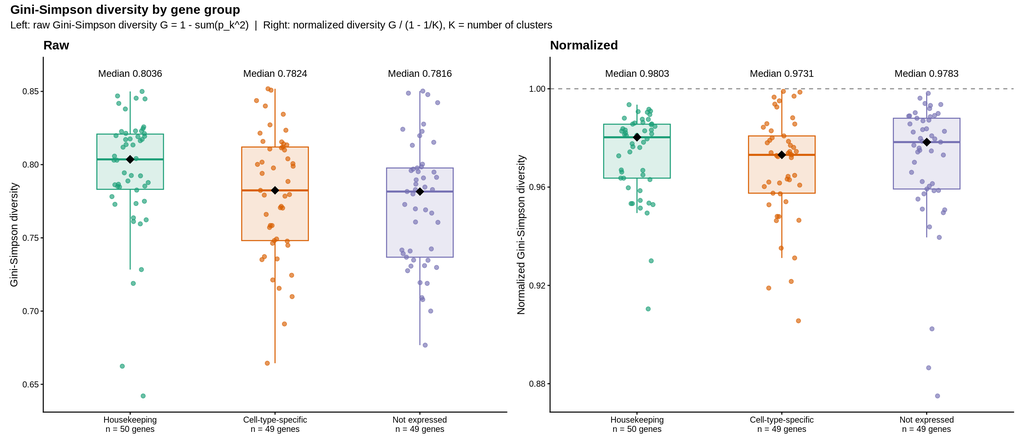

```r
p <- plot_group_pair(gini_plot, GINI_SPEC)
save_gini_pdf(p, "01_gene_group_entropy.pdf", 15, 6.5)
p
```

### 2. Gini-Simpson diversity by Puffin dominant motif

Each point is one gene, grouped by its Puffin dominant motif. Motifs are ordered by median raw diversity. Left: raw diversity, right: normalized diversity

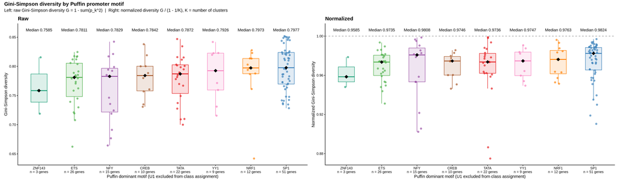

```r
p <- plot_motif_pair(gini_plot, GINI_SPEC)
save_gini_pdf(p, "02_entropy_by_puffin_motif.pdf", 22, 6.5)
p
```

### 3. Gini-Simpson diversity and +1 nucleosome start position

Each point is one gene. The +1 coordinate is the same as in the nucleosome section. Left: raw diversity, right: normalized diversity

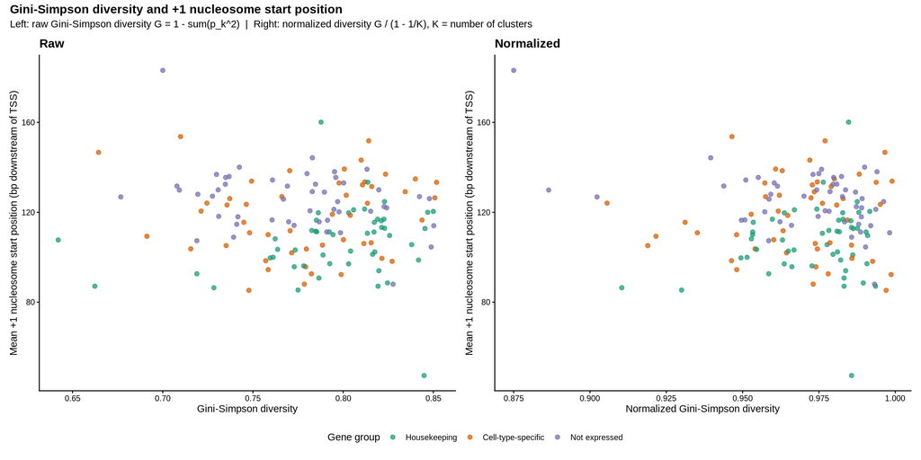

```r
p <- plot_plus1_pair(gini_plot, GINI_SPEC)
save_gini_pdf(p, "03_entropy_vs_plus1_start.pdf", 14, 7)
p
```

### 4. Gini-Simpson diversity and footprint presence at promoters

Footprint fractions are the nucleosome-section ones (fibers with a 10-<30, 30-<60 or 60-80 bp footprint overlapping TSS -100..+100 bp). Left: raw diversity, right: normalized diversity

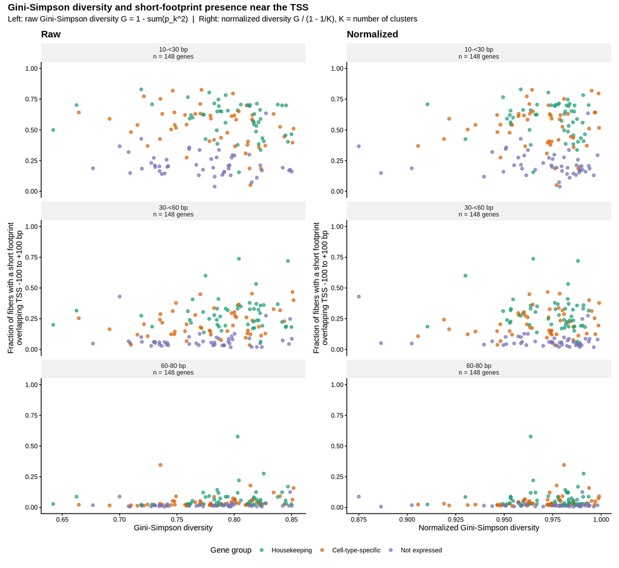

```r
p <- plot_footprint_pair(gini_fp, GINI_SPEC)
save_gini_pdf(p, "04_entropy_vs_short_footprints.pdf", 12, 11)
p
```

### 5. gene ranking by raw and normalized Gini-Simpson diversity

Each row is one gene, ranked from highest diversity at the top to lowest at the bottom; each panel has its own gene order. Left: raw Gini-Simpson diversity, right: normalized Gini-Simpson diversity (evenness only)

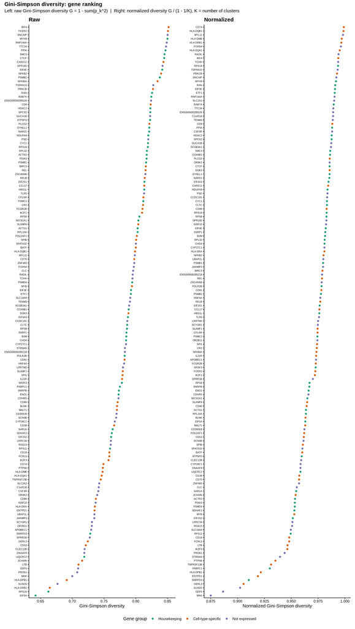

```r
p <- plot_ranking_pair(gini_plot, GINI_SPEC)
save_gini_pdf(p, "05_entropy_ranking.pdf", 12, ranking_height(gini_plot))
p
```